# Выпускной проект: e-commerce

# Содержание

## Описание проекта

В данном исследовании проводится анализ текущей бизнес-ситуации небольшого магазина товаров для дома, проводится сегментация покупателей по профилю потребления и даются рекомендации бизнесу на основе проведённого анализа данных.

**Основные задачи**:

- проанализировать основные показатели бизнеса: суммы продаж, количество заказов, средний чек, сезонность
- провести сегментацию покупателей по профилям потребления
- дать развёрнутые рекомендации по каждому кластеру: когда и какие рекламные предложения рассылать, как увеличить количество продаж, сумму покупок, повысить возвращаемость покупателей

**План работы**:

- предобработка данных: изменение типов данных, проверка на скрытые дубликаты
- подготовка данных к исследованию: создание категорий товаров
- анализ показателей бизнеса: продажи по годам, сезонам, категориям товаров; среднее количество заказов на покупателя и средний чек
- сегментация покупателей по профилям потребления при помощи KMeans
- проверка качества разбивки кластеров при помощи статистических гипотез: различия в среднем чеке между кластерами при качественной разбивке должны быть статистическими значимыми
- описание "портрета" пользователя из каждого кластера, визуализация различий между кластерами
- рекомендации по предложениям и рассылкам для каждого кластера
- презентация
- дашборд

**Описание данных**:

В исследовании используются данные, предоставленные самим магазином товаров для дома. Это сведения о покупках за несколько лет: дата заказа, идентификатор покупателя, номер заказа, наименование продукта, количество, цена.

## Открытие данных

Импортируем необходимые библиотеки:

```python
import pandas as pd
import os
from functools import reduce

from matplotlib import pyplot as plt
import matplotlib.gridspec as gridspec
import seaborn as sns

import datetime as dt
from datetime import datetime, date, timedelta

import numpy as np
import math as mth
from scipy import stats as st

from sklearn.preprocessing import StandardScaler
from scipy.cluster import hierarchy
from scipy.cluster.hierarchy import dendrogram, linkage
from sklearn.cluster import KMeans

import warnings
warnings.filterwarnings("ignore")
```

Открываем файл:

```python
google_id = "1DkqEQWZoHh22YrsYcNUxSzlhgFqdl0tf"
df = pd.read_csv(f"https://drive.google.com/uc?export=download&id={google_id}" )
```

Для ознакомления и проверки данных будем использовать собственную функцию:

```python
def my_check_function (dataset):
    '''Функция для ознакомления и проверки даных'''
    print('Размер датасета (количество строк, столбцов):')
    print(dataset.shape)
    print('Как выглядят случайные 5 строк:')
    display(dataset.sample(5, random_state=42))
    print()
    print('Общая информация о данных, наименования столбцов, типы данных:')
    print(dataset.info())
    print()
    print('Есть ли пропуски, сколько их:')
    print(dataset.isna().sum())
    print('Доля пропущенных значений:')
    print(dataset.isna().mean())
    print()
    print('Есть ли явные дубликаты, сколько их:')
    print(dataset.duplicated().sum())
    print('Доля явных дубликатов:')
    print(dataset.duplicated().mean())
    print()
    print('Подробное описание данных:')
    display(dataset.describe())
```

```python
my_check_function(df)
```

```
Размер датасета (количество строк, столбцов):
(7474, 6)
Как выглядят случайные 5 строк:
```

|  | date | customer_id | order_id | product | quantity | price |
| --- | --- | --- | --- | --- | --- | --- |
| 1297 | 2018122113 | c971fb21-d54c-4134-938f-16b62ee86d3b | 69503 | Сумка-тележка хозяйственная Gimi Easy Go синяя | 1 | 1649.0 |
| 576 | 2018110116 | fb9704c7-8106-4e7a-a2a4-70a97550deb4 | 68822 | Муляж Красное яблоко мини полиуретан d-6 см | 15 | 20.0 |
| 6775 | 2019110503 | 72ec5d18-0d86-438a-aa6e-39ce8bdb2310 | 112220 | Сумка-тележка 2-х колесная Gimi Galaxy черная | 1 | 2811.5 |
| 5444 | 2019061813 | 1d6c8c1f-a799-4418-9af2-1ded47d7a85c | 14833 | Рассада Кабачка сорт Аэронавт, кассета по 6шт | 1 | 120.0 |
| 4974 | 2019061007 | 1d6c8c1f-a799-4418-9af2-1ded47d7a85c | 14833 | Рассада Огурец Кристина ячейки по 6 шт Е6 | 1 | 120.0 |

```
Общая информация о данных, наименования столбцов, типы данных:
<class 'pandas.core.frame.DataFrame'>
RangeIndex: 7474 entries, 0 to 7473
Data columns (total 6 columns):
 #   Column       Non-Null Count  Dtype
---  ------       --------------  -----
 0   date         7474 non-null   int64
 1   customer_id  7474 non-null   object
 2   order_id     7474 non-null   int64
 3   product      7474 non-null   object
 4   quantity     7474 non-null   int64
 5   price        7474 non-null   float64
dtypes: float64(1), int64(3), object(2)
memory usage: 350.5+ KB
None

Есть ли пропуски, сколько их:
date           0
customer_id    0
order_id       0
product        0
quantity       0
price          0
dtype: int64
Доля пропущенных значений:
date           0.0
customer_id    0.0
order_id       0.0
product        0.0
quantity       0.0
price          0.0
dtype: float64

Есть ли явные дубликаты, сколько их:
0
Доля явных дубликатов:
0.0

Подробное описание данных:
```

|  | date | order_id | quantity | price |
| --- | --- | --- | --- | --- |
| count | 7.474000e+03 | 7474.000000 | 7474.000000 | 7474.000000 |
| mean | 2.018913e+09 | 49449.884265 | 2.362858 | 478.737501 |
| std | 4.278878e+05 | 32679.642404 | 14.500497 | 901.615895 |
| min | 2.018100e+09 | 12624.000000 | 1.000000 | 9.000000 |
| 25% | 2.019022e+09 | 14833.000000 | 1.000000 | 97.000000 |
| 50% | 2.019051e+09 | 68768.000000 | 1.000000 | 135.000000 |
| 75% | 2.019063e+09 | 71257.750000 | 1.000000 | 439.000000 |
| max | 2.020013e+09 | 112789.000000 | 1000.000000 | 14917.000000 |

### Вывод

- в нашем распоряжении данные из 7474 строк, 6 столбцов
- здесь нет пропусков и явных дубликатов
- для дальнейшей работы нам понадобится изменить тип данных в столбце date

## Предобработка и подготовка данных

### Изменение типов данных

Изменим тип данных в столбце date:

```python
df['date'] = df['date'].astype('str').apply(lambda x: x + "0000")
df['date'] = df['date'].astype(str)
df['date'] = df['date'].str[:8]
df['date'] = pd.to_datetime(df['date'])
print(f'Тип данных столбца: {df.dtypes["date"]}')
```

```
Тип данных столбца: datetime64[ns]
```

### Выделение года, месяца, времен года из дат

Для дальнейшего исследования нам пригодится информация о годе и месяце оформления заказов. Добавим такие данные в датасет:

```python
df['year'] = pd.to_datetime(df['date']).dt.year.astype(str)
df['month'] = pd.to_datetime(df['date']).dt.month
df['month_name'] = pd.to_datetime(df['date']).dt.month_name()
df.head()
```

|  | date | customer_id | order_id | product | quantity | price | year | month | month_name |
| --- | --- | --- | --- | --- | --- | --- | --- | --- | --- |
| 0 | 2018-10-01 | ee47d746-6d2f-4d3c-9622-c31412542920 | 68477 | Комнатное растение в горшке Алое Вера, d12, h30 | 1 | 142.0 | 2018 | 10 | October |
| 1 | 2018-10-01 | ee47d746-6d2f-4d3c-9622-c31412542920 | 68477 | Комнатное растение в горшке Кофе Арабика, d12,... | 1 | 194.0 | 2018 | 10 | October |
| 2 | 2018-10-01 | ee47d746-6d2f-4d3c-9622-c31412542920 | 68477 | Радермахера d-12 см h-20 см | 1 | 112.0 | 2018 | 10 | October |
| 3 | 2018-10-01 | ee47d746-6d2f-4d3c-9622-c31412542920 | 68477 | Хризолидокарпус Лутесценс d-9 см | 1 | 179.0 | 2018 | 10 | October |
| 4 | 2018-10-01 | ee47d746-6d2f-4d3c-9622-c31412542920 | 68477 | Циперус Зумула d-12 см h-25 см | 1 | 112.0 | 2018 | 10 | October |

Создадим функцию для определения названий времен года:

```python
def season (month_name):
    """
    Возвращает название времени года, исходя из названия месяца
    """
    winter_list = ['December', 'January', 'February']
    spring_list = ['March', 'April', 'May']
    summer_list = ['June', 'July', 'August']
    autumn_list = ['September', 'October', 'November']

    for name in winter_list:
        if name in month_name:
            return 'Winter'
    for name in spring_list:
        if name in month_name:
            return 'Spring'
    for name in summer_list:
        if name in month_name:
            return 'Summer'
    for name in autumn_list:
        if name in month_name:
            return 'Autumn'
```

Добавляем данные в датасет:

```python
df['season'] = df['month_name'].apply(season)
```

И добавляем порядковый номер времени года (начиная с зимы):

```python
def season_number (season):
    """
    Возвращает порядковый номер времени года, исходя из названия
    """

    if season =="Winter":
            return 1
    if season =="Spring":
            return 2
    if season =="Summer":
            return 3
    if season =="Autumn":
            return 4
```

```python
df['season_number'] = df['season'].apply(season_number)
df.head()
```

|  | date | customer_id | order_id | product | quantity | price | year | month | month_name | season | season_number |
| --- | --- | --- | --- | --- | --- | --- | --- | --- | --- | --- | --- |
| 0 | 2018-10-01 | ee47d746-6d2f-4d3c-9622-c31412542920 | 68477 | Комнатное растение в горшке Алое Вера, d12, h30 | 1 | 142.0 | 2018 | 10 | October | Autumn | 4 |
| 1 | 2018-10-01 | ee47d746-6d2f-4d3c-9622-c31412542920 | 68477 | Комнатное растение в горшке Кофе Арабика, d12,... | 1 | 194.0 | 2018 | 10 | October | Autumn | 4 |
| 2 | 2018-10-01 | ee47d746-6d2f-4d3c-9622-c31412542920 | 68477 | Радермахера d-12 см h-20 см | 1 | 112.0 | 2018 | 10 | October | Autumn | 4 |
| 3 | 2018-10-01 | ee47d746-6d2f-4d3c-9622-c31412542920 | 68477 | Хризолидокарпус Лутесценс d-9 см | 1 | 179.0 | 2018 | 10 | October | Autumn | 4 |
| 4 | 2018-10-01 | ee47d746-6d2f-4d3c-9622-c31412542920 | 68477 | Циперус Зумула d-12 см h-25 см | 1 | 112.0 | 2018 | 10 | October | Autumn | 4 |

### Проверка на скрытые дубликаты

У нас нет явных дубликатов, но, возможно, есть скрытые.

Проверим подряд все подозрительные варианты, когда данные дублируются во всех столбцах, кроме одного.

Все данные дублируются, за исключением столбца date:

```python
(df[df.duplicated(subset=['customer_id', 'order_id', 'product', 'quantity', 'price'], keep=False)]
.sort_values(by=['customer_id', 'order_id', 'product']))
```

|  | date | customer_id | order_id | product | quantity | price | year | month | month_name | season | season_number |
| --- | --- | --- | --- | --- | --- | --- | --- | --- | --- | --- | --- |
| 2237 | 2019-03-07 | 0184f535-b60a-4914-a982-231e3f615206 | 14566 | Пеларгония розебудная Margaretha укорененный ч... | 1 | 135.0 | 2019 | 3 | March | Spring | 2 |
| 2241 | 2019-03-07 | 0184f535-b60a-4914-a982-231e3f615206 | 14566 | Пеларгония розебудная Margaretha укорененный ч... | 1 | 135.0 | 2019 | 3 | March | Spring | 2 |
| 2238 | 2019-03-07 | 0184f535-b60a-4914-a982-231e3f615206 | 14566 | Пеларгония розебудная Mary укорененный черенок | 1 | 135.0 | 2019 | 3 | March | Spring | 2 |
| 2242 | 2019-03-07 | 0184f535-b60a-4914-a982-231e3f615206 | 14566 | Пеларгония розебудная Mary укорененный черенок | 1 | 135.0 | 2019 | 3 | March | Spring | 2 |
| 2239 | 2019-03-07 | 0184f535-b60a-4914-a982-231e3f615206 | 14566 | Пеларгония розебудная Prins Nikolai укорененны... | 1 | 135.0 | 2019 | 3 | March | Spring | 2 |
| ... | ... | ... | ... | ... | ... | ... | ... | ... | ... | ... | ... |
| 6716 | 2019-10-30 | ffaeab76-3a8d-49ee-860f-17273b2fc8a2 | 73136 | Таз пластмассовый со стиральной доской (Иж), 1... | 1 | 397.0 | 2019 | 10 | October | Autumn | 4 |
| 6728 | 2019-10-31 | ffaeab76-3a8d-49ee-860f-17273b2fc8a2 | 73136 | Таз пластмассовый со стиральной доской (Иж), 1... | 1 | 397.0 | 2019 | 10 | October | Autumn | 4 |
| 6729 | 2019-10-31 | ffaeab76-3a8d-49ee-860f-17273b2fc8a2 | 73136 | Таз пластмассовый со стиральной доской (Иж), 1... | 1 | 397.0 | 2019 | 10 | October | Autumn | 4 |
| 1208 | 2018-12-14 | ffb5976a-7a4d-460b-95c4-5ffaba31cb24 | 69369 | Новогоднее дерево Ель канадская Коника ртк 343... | 1 | 389.0 | 2018 | 12 | December | Winter | 1 |
| 1217 | 2018-12-15 | ffb5976a-7a4d-460b-95c4-5ffaba31cb24 | 69369 | Новогоднее дерево Ель канадская Коника ртк 343... | 1 | 389.0 | 2018 | 12 | December | Winter | 1 |

2369 rows × 11 columns

Всё дублируется, кроме столбца customer_id:

```python
(df[df.duplicated(subset=['date', 'order_id', 'product', 'quantity', 'price'], keep=False)]
.sort_values(by=['date', 'order_id','product']))
```

|  | date | customer_id | order_id | product | quantity | price | year | month | month_name | season | season_number |
| --- | --- | --- | --- | --- | --- | --- | --- | --- | --- | --- | --- |
| 58 | 2018-10-02 | b731df05-98fa-4610-8496-716ec530a02c | 68474 | Доска гладильная Eurogold Professional 130х48 ... | 1 | 3299.0 | 2018 | 10 | October | Autumn | 4 |
| 59 | 2018-10-02 | b731df05-98fa-4610-8496-716ec530a02c | 68474 | Доска гладильная Eurogold Professional 130х48 ... | 1 | 3299.0 | 2018 | 10 | October | Autumn | 4 |
| 60 | 2018-10-02 | b731df05-98fa-4610-8496-716ec530a02c | 68474 | Доска гладильная Eurogold Professional 130х48 ... | 1 | 3299.0 | 2018 | 10 | October | Autumn | 4 |
| 80 | 2018-10-04 | 32de7df8-8d4f-4c84-a7b9-c41d00dd83ba | 68522 | Эвкалипт Гунни d-17 см h-60 см | 1 | 1409.0 | 2018 | 10 | October | Autumn | 4 |
| 94 | 2018-10-04 | 32de7df8-8d4f-4c84-a7b9-c41d00dd83ba | 68522 | Эвкалипт Гунни d-17 см h-60 см | 1 | 1409.0 | 2018 | 10 | October | Autumn | 4 |
| ... | ... | ... | ... | ... | ... | ... | ... | ... | ... | ... | ... |
| 6706 | 2019-10-28 | 57cc80a2-2610-4eef-9457-e7c3bf0c72f0 | 70960 | Сумка-тележка 2-х колесная Gimi Argo красная | 1 | 1087.0 | 2019 | 10 | October | Autumn | 4 |
| 6704 | 2019-10-28 | cb65d08a-dae7-4890-aef0-bb9f79055e02 | 73108 | Мирт d-9 см h-15 см | 1 | 134.0 | 2019 | 10 | October | Autumn | 4 |
| 6711 | 2019-10-28 | cb65d08a-dae7-4890-aef0-bb9f79055e02 | 73108 | Мирт d-9 см h-15 см | 1 | 134.0 | 2019 | 10 | October | Autumn | 4 |
| 6728 | 2019-10-31 | ffaeab76-3a8d-49ee-860f-17273b2fc8a2 | 73136 | Таз пластмассовый со стиральной доской (Иж), 1... | 1 | 397.0 | 2019 | 10 | October | Autumn | 4 |
| 6729 | 2019-10-31 | ffaeab76-3a8d-49ee-860f-17273b2fc8a2 | 73136 | Таз пластмассовый со стиральной доской (Иж), 1... | 1 | 397.0 | 2019 | 10 | October | Autumn | 4 |

1518 rows × 11 columns

Всё дублируется, кроме order_id:

```python
(df[df.duplicated(subset=['date', 'customer_id', 'product', 'quantity', 'price'], keep=False)]
.sort_values(by=['date', 'customer_id', 'product']))
```

|  | date | customer_id | order_id | product | quantity | price | year | month | month_name | season | season_number |
| --- | --- | --- | --- | --- | --- | --- | --- | --- | --- | --- | --- |
| 58 | 2018-10-02 | b731df05-98fa-4610-8496-716ec530a02c | 68474 | Доска гладильная Eurogold Professional 130х48 ... | 1 | 3299.0 | 2018 | 10 | October | Autumn | 4 |
| 59 | 2018-10-02 | b731df05-98fa-4610-8496-716ec530a02c | 68474 | Доска гладильная Eurogold Professional 130х48 ... | 1 | 3299.0 | 2018 | 10 | October | Autumn | 4 |
| 60 | 2018-10-02 | b731df05-98fa-4610-8496-716ec530a02c | 68474 | Доска гладильная Eurogold Professional 130х48 ... | 1 | 3299.0 | 2018 | 10 | October | Autumn | 4 |
| 80 | 2018-10-04 | 32de7df8-8d4f-4c84-a7b9-c41d00dd83ba | 68522 | Эвкалипт Гунни d-17 см h-60 см | 1 | 1409.0 | 2018 | 10 | October | Autumn | 4 |
| 94 | 2018-10-04 | 32de7df8-8d4f-4c84-a7b9-c41d00dd83ba | 68522 | Эвкалипт Гунни d-17 см h-60 см | 1 | 1409.0 | 2018 | 10 | October | Autumn | 4 |
| ... | ... | ... | ... | ... | ... | ... | ... | ... | ... | ... | ... |
| 6706 | 2019-10-28 | 57cc80a2-2610-4eef-9457-e7c3bf0c72f0 | 70960 | Сумка-тележка 2-х колесная Gimi Argo красная | 1 | 1087.0 | 2019 | 10 | October | Autumn | 4 |
| 6704 | 2019-10-28 | cb65d08a-dae7-4890-aef0-bb9f79055e02 | 73108 | Мирт d-9 см h-15 см | 1 | 134.0 | 2019 | 10 | October | Autumn | 4 |
| 6711 | 2019-10-28 | cb65d08a-dae7-4890-aef0-bb9f79055e02 | 73108 | Мирт d-9 см h-15 см | 1 | 134.0 | 2019 | 10 | October | Autumn | 4 |
| 6728 | 2019-10-31 | ffaeab76-3a8d-49ee-860f-17273b2fc8a2 | 73136 | Таз пластмассовый со стиральной доской (Иж), 1... | 1 | 397.0 | 2019 | 10 | October | Autumn | 4 |
| 6729 | 2019-10-31 | ffaeab76-3a8d-49ee-860f-17273b2fc8a2 | 73136 | Таз пластмассовый со стиральной доской (Иж), 1... | 1 | 397.0 | 2019 | 10 | October | Autumn | 4 |

1550 rows × 11 columns

Сохраним наши изначальные данные в отдельной переменной, а для дальнейшей работы будем использовать данные без скрытых дубликатов.

```python
df_raw = df

df = df.drop_duplicates(subset=['customer_id', 'order_id', 'product', 'quantity', 'price'])
df = df.drop_duplicates(subset=['date', 'order_id', 'product', 'quantity', 'price'])
df = (df.drop_duplicates(subset=['date', 'customer_id', 'product', 'quantity', 'price'])
      .sort_values(by=['date', 'order_id']).reset_index(drop=True))
```

Проверим данные ещё на наличие заказов, которые числятся более чем за одним покупателем:

```python
order_cust_dupl = (df.groupby('order_id',as_index=False).agg({'customer_id':'nunique'})
                   .sort_values(by='order_id'))
order_cust_dupl = order_cust_dupl.query('customer_id > 1')
order_cust_dupl
```

|  | order_id | customer_id |
| --- | --- | --- |
| 248 | 14872 | 2 |
| 516 | 68785 | 2 |
| 814 | 69310 | 2 |
| 829 | 69345 | 2 |
| 859 | 69410 | 2 |
| 899 | 69485 | 3 |
| 930 | 69531 | 2 |
| 1062 | 69833 | 2 |
| 1195 | 70114 | 2 |
| 1437 | 70542 | 2 |
| 1489 | 70631 | 2 |
| 1625 | 70903 | 2 |
| 1645 | 70946 | 2 |
| 1706 | 71054 | 2 |
| 1892 | 71461 | 2 |
| 1901 | 71480 | 3 |
| 1926 | 71542 | 2 |
| 1987 | 71648 | 2 |
| 1991 | 71663 | 2 |
| 2255 | 72188 | 2 |
| 2551 | 72778 | 2 |
| 2558 | 72790 | 2 |
| 2591 | 72845 | 3 |
| 2657 | 72950 | 2 |

Также уберём их из датасета:

```python
orders = order_cust_dupl['order_id']
df = df[~df.isin(df.query('order_id in @orders').drop_duplicates(subset=['order_id']))].dropna()
len(df)

print(f'Количество строк в изначальном датасете: {len(df_raw)}')
print(f'Количество строк в датасете без скрытых дубликатов: {len(df)}')
print(f'Убрано строк: {len(df_raw) - len(df)}, это {(len(df_raw) - len(df))/len(df_raw):.0%} от начального объёма')
```

```
Количество строк в изначальном датасете: 7474
Количество строк в датасете без скрытых дубликатов: 5558
Убрано строк: 1916, это 26% от начального объёма
```

У нас оказалось достаточно много дубликатов, однако для дальнейшего исследования оставшихся данных должно хватить.

### Создание категорий товаров

Выделим информацию о категориях товаров в отдельный столбец:

```python
def product_category (product):
    """
    Возвращает категорию товара по значению product
    на основании вхождения части названия в какой-либо из списков
    """
    plants_list = ['черенок', 'ассада', 'растение', 'd-', 'Пеларгония', 'Герань', 'Радермахера', 'Хризолидокарпус',
                  'Циперус Зумула', 'Шеффлера Лузеана', 'Юкка нитчатая', 'Петуния', 'Калибрахоа', 'Бакопа', 'Декабрист',
                  'Фуксия', 'Эвкалипт', 'Хлорофитум', 'Настурция', 'Дендробиум', 'томата', 'Арбуз', 'Роза', 'Котовник',
                  'Колокольчик', 'Овсянница', 'Вербейник', 'Афеляндра', 'Тимьян', 'Лобелия', 'Мимоза', 'Гвоздика', 'Флокс',
                  'Суккулент', 'Эхеверия', 'Лаванда', 'Алоэ', 'Незабудка', 'Укроп', 'Фикус', 'Аптения', 'Литопс', 'Кофе',
                  'Антуриум', 'Примула', 'Дыня', 'Вербена', 'Мединилла', 'Ранункулус', 'Фиттония', 'Каланхое', 'Камнеломка',
                  'Гардения', 'Петрушка', 'Нивянник', 'Лавр', 'Чабер', 'Шеффлера', 'Гипсофила', 'Фиалка', 'Клубника',
                   'Клен', 'Ясколка', 'Пуансеттия', 'Мирт', 'Седум', 'Томат', 'Калатея', 'Физостегия', 'Эхинокактус',
                   'Кореопсис', 'Космея', 'Гиацинт', 'Алиссум', 'Зверобой', 'Лантана', 'Мята', 'Хамедорея', 'Цинния',
                   'Азалия', 'Цикламен', 'Калла', 'Молодило', 'Спатифиллум', 'Бархатцы', 'Нефролепис', 'Нефролепис', 'Ель',
                   'Огурец', 'Гортензия', 'Виола', 'Вероника', 'Цитрофортунелла', 'Папоротник', 'Платикодон', 'Бегония',
                   'Хризантема', 'Бальзамин', 'Тюльпан', 'Пиретрум', 'Капуста', 'Энотера', 'виноград', 'Кипарисовик',
                   'Аквилегия', 'Салат', 'в кассете', 'Лапчатка', 'Календула', 'Лаватера', 'Морковь', 'Годеция', 'Маттиола',
                   'Цинерария', 'Эшшольция', 'Горох', 'Земляника', 'Георгина', 'Смолевка', 'Эхинацея', 'Лилейник', 'Осина',
                   'Гайлардия', 'Астра', 'Монарда', 'Рудбекия', 'Хоста', 'Барвинок', 'Бузульник', 'Солидаго', 'Бадан',
                   'Анемона']
    transport_list = ['умка', 'ележка', 'тремянк']
    cleaning_list = ['ушилка', 'аз', 'етка', 'ладильн', 'рищеп', 'одрукавник', 'орыто', 'Швабра', 'чистк', 'Веник', 'мыть',
                    'Тряпкодержатель', 'Окномойка', 'полотенце', 'ржавчин', 'ведр', 'Перчатки', 'засор', 'Ковш', 'стирк',
                    'Ёрш', 'Стиральный', 'Чистящий', 'Вантуз', 'ыло', 'аста', 'ванн', 'швабр', 'Совок', 'Утюг', 'Губка',
                    'Фен', 'Антижир', 'маска', 'Тряпка', 'Кондиционер', 'Отбеливатель', 'Ткань', 'Антинакипин','Пылесос']
    decor_list = ['уляж', 'скуственн', 'скусственн', 'овогодн', 'озатор', 'сувенир']
    storage_list = ['ехол', 'ешалк', 'вешал','рючок', 'орзин', 'щик', 'тяжка', 'онтейнер', 'оробка', 'хранени', 'Бак',
                   'Короб', 'Ведро', 'Урна', 'Кофр', 'Бидон']
    kitchen_list = ['ковород', 'арелка', 'илка', 'ружка', 'круж','ожка', 'ложк', 'Нож', 'нож', 'выпечк', 'Салатник',
                    'анка', 'варка', 'увшин', 'Хлебница', 'фужер', 'росеиватель', 'пароварка', 'Миксер', 'Бульонница',
                   'Чайник', 'кухонн', 'Электроштопор', 'посудомоечн', 'Терка', 'такан', 'салфет', 'Блюдо', 'Термос',
                   'бокал', 'Блюдце', 'кекс', 'Кастрюля', 'Орехоколка', 'Сахарница', 'Сито', 'Масленка', 'Толкушка',
                   'Противень', 'Лоток', 'Сотейник', 'Соковыжималка', 'Чайный', 'посуд', 'столов', 'Картофелемялка',
                    'Отделитель', 'Половник', 'кондитер', 'Миска', 'чеснока', 'Емкость', 'Скалка', 'Венчик', 'Тортница']
    interior_list = ['оврик', 'овер', 'овёр', 'ковр','одставк', 'Штора', 'катерть', 'Полк', 'Плед', 'Комод', 'Покрывало',
                    'кашпо', 'остельн', 'ростын', 'аматрасник', 'Наматрацник', 'Ключница', 'Светильник', 'Подголовник',
                     'Карниз', 'пуф', 'деял', 'одушк', 'аволочк','теллаж', 'олотен', 'Держатель', 'Фоторамка', 'Этажерка',
                    'Обувница']
    household_list = ['Фал', 'Штангенциркуль', 'зажигал', 'Петля', 'Шпингалет', 'Весы', 'Термометр', 'Линейка', 'Котел',
                     'Крепеж', 'Пружина', 'Кольца', 'Сверло', 'сверел', 'скоба', 'сварка', 'Шнур', 'Лопатка', 'угольник',
                     'блок', 'Шило', 'асадка', 'Уголок', 'Кипятильник', 'пробки', 'Скребок', 'инструмент', 'напильник',
                     'Фиксатор', 'Ручка', 'Шпагат', 'Мешок', 'Завертка']

    for item in plants_list:
        if item in product:
            return 'цветы и растения'
    for item in transport_list:
        if item in product:
            return 'транспортировка'
    for item in cleaning_list:
        if item in product:
            return 'уборка'
    for item in decor_list:
        if item in product:
            return 'декор'
    for item in storage_list:
        if item in product:
            return 'хранение'
    for item in kitchen_list:
        if item in product:
            return 'посуда'
    for item in interior_list:
        if item in product:
            return 'интерьер'
    for item in household_list:
        if item in product:
            return 'хозяйство'
```

Применяем функцию, создаём новый столбец:

```python
df['product_category'] = df['product'].apply(product_category)
```

Проверяем, всё ли заполнили:

```python
df['product_category'].isna().sum()
```

```
0
```

Создадим номер категории, чтобы у нас были не только словесные, но и числовые данные:

```python
def product_category_number (product_category):
    """
    Возвращает номер категории товара
    """
    if product_category == 'цветы и растения':
        return 1
    if product_category == 'транспортировка':
        return 2
    if product_category == 'уборка':
        return 3
    if product_category == 'декор':
        return 4
    if product_category == 'хранение':
        return 5
    if product_category == 'посуда':
        return 6
    if product_category == 'интерьер':
        return 7
    if product_category == 'хозяйство':
        return 8
```

```python
df['product_category_number'] = df['product_category'].apply(product_category_number)
```

Посмотрим случайные строки в датасете:

```python
df.sample(5, random_state=50)
```

|  | date | customer_id | order_id | product | quantity | price | year | month | month_name | season | season_number | product_category | product_category_number |
| --- | --- | --- | --- | --- | --- | --- | --- | --- | --- | --- | --- | --- | --- |
| 2049 | 2019-03-20 | b6ba5131-b839-451c-b8aa-be517d61f66a | 70801.0 | Тележка хозяйственная 4-колесная большая тип-7... | 1.0 | 750.0 | 2019 | 3.0 | March | Spring | 2.0 | транспортировка | 2 |
| 1726 | 2019-02-25 | 7984e329-7bbf-4c36-9b98-c5f88feebd43 | 70450.0 | Эхеверия Микс d-5 см | 5.0 | 104.0 | 2019 | 2.0 | February | Winter | 1.0 | цветы и растения | 1 |
| 1193 | 2018-12-26 | 8124288d-faf6-4d24-944a-a5f0ed56c91a | 69624.0 | Тележка багажная DELTA ТБР-23 грузоподъемность... | 1.0 | 1049.0 | 2018 | 12.0 | December | Winter | 1.0 | транспортировка | 2 |
| 2641 | 2019-04-24 | 2a0acc09-e343-4f92-b5c0-f598ef2b07d4 | 14688.0 | томата (помидор) Большая желтая зебра №10 сорт... | 2.0 | 38.0 | 2019 | 4.0 | April | Spring | 2.0 | цветы и растения | 1 |
| 5545 | 2020-01-26 | b833edab-f32c-483e-8662-cb85909211a2 | 105869.0 | Вербена ампельная, диам. 12 см | 1.0 | 142.0 | 2020 | 1.0 | January | Winter | 1.0 | цветы и растения | 1 |

### Расчёт чека заказа

Добавим в датасет данные о сумме каждого заказа. Разобьём задачу на части.

Сначала добавляем сведения о стоимости каждого товара, в зависимости от количества купленных единиц:

```python
df['price_total'] = df['quantity'] * df['price']
```

Теперь рассчитываем для каждого заказа его сумму:

```python
df_receipt = (df.groupby('order_id').agg({'price_total':'sum'}).reset_index().rename_axis(None, axis=1)
                .rename(columns={'price_total':'order_receipt'}))
df_receipt
```

|  | order_id | order_receipt |
| --- | --- | --- |
| 0 | 12624.0 | 375.0 |
| 1 | 13547.0 | 684.0 |
| 2 | 14480.0 | 359.0 |
| 3 | 14481.0 | 600.0 |
| 4 | 14482.0 | 376.0 |
| ... | ... | ... |
| 3496 | 112722.0 | 450.0 |
| 3497 | 112732.0 | 90.0 |
| 3498 | 112767.0 | 38.0 |
| 3499 | 112779.0 | 172.0 |
| 3500 | 112789.0 | 2698.0 |

3501 rows × 2 columns

Добавляем эти данные в основную таблицу:

```python
df = df.merge(df_receipt, how='left', on='order_id')
df.sort_values(by='order_id').head()
```

|  | date | customer_id | order_id | product | quantity | price | year | month | month_name | season | season_number | product_category | product_category_number | price_total | order_receipt |
| --- | --- | --- | --- | --- | --- | --- | --- | --- | --- | --- | --- | --- | --- | --- | --- |
| 3584 | 2019-06-02 | d17861fa-db5f-4de4-93fd-dc5e60d24d3e | 12624.0 | Осина обыкновенная, Высота 25-50 см | 1.0 | 150.0 | 2019 | 6.0 | June | Summer | 3.0 | цветы и растения | 1 | 150.0 | 375.0 |
| 3585 | 2019-06-02 | d17861fa-db5f-4de4-93fd-dc5e60d24d3e | 12624.0 | Осина обыкновенная, Высота 50-100 см | 1.0 | 225.0 | 2019 | 6.0 | June | Summer | 3.0 | цветы и растения | 1 | 225.0 | 375.0 |
| 97 | 2018-10-05 | b80e4826-7218-4bf9-ac08-eb2c81ab3f62 | 13547.0 | Рассада зелени для кухни Лаванды в кассете по ... | 1.0 | 315.0 | 2018 | 10.0 | October | Autumn | 4.0 | цветы и растения | 1 | 315.0 | 684.0 |
| 99 | 2018-10-05 | b80e4826-7218-4bf9-ac08-eb2c81ab3f62 | 13547.0 | Рассада зелени для кухни Тимьяна в кассете по ... | 1.0 | 162.0 | 2018 | 10.0 | October | Autumn | 4.0 | цветы и растения | 1 | 162.0 | 684.0 |
| 98 | 2018-10-05 | b80e4826-7218-4bf9-ac08-eb2c81ab3f62 | 13547.0 | Рассада зелени для кухни Розмарина в кассете п... | 1.0 | 207.0 | 2018 | 10.0 | October | Autumn | 4.0 | цветы и растения | 1 | 207.0 | 684.0 |

### Вывод

С этими данными мы можем приступать к следующему разделу.

## Исследовательский анализ данных

Посмотрим на общую картину бизнеса с разных сторон.

Зададим цветовое решение проекта:

```python
color = '#c4cbe3'
```

### Ассортимент товаров по категориям

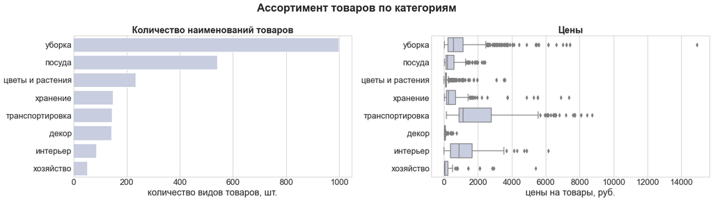

```python
plt.figure(figsize=(20, 10))
sns.set(font_scale=1.5)
plt.style.use('seaborn-whitegrid')
plt.suptitle('Ассортимент товаров по категориям', fontweight='bold')

ax1 = plt.subplot(2, 2, 1)
data = (df.groupby(['product_category', 'product_category_number'], as_index=False).agg({'product':'nunique'})
        .sort_values(by='product', ascending=False))
sns.barplot(data=data, y='product_category', x='product', color=color)
plt.title('Количество наименований товаров', fontweight='bold')
plt.xlabel('количество видов товаров, шт.')
plt.ylabel('')

ax2 = plt.subplot(2, 2, 2, sharey=ax1)
sns.boxplot(data=df, y='product_category', x='price', color=color)
plt.title('Цены', fontweight='bold')
plt.xlabel('цены на товары, руб.')
plt.ylabel('')

plt.tight_layout()
plt.show();
```

### Продажи по годам: количество заказов и сумма продаж

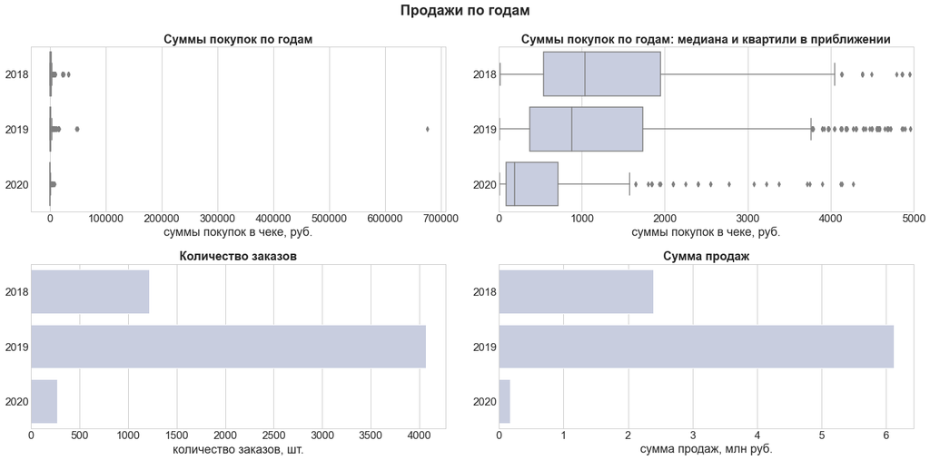

```python
plt.figure(figsize=(20, 10))
sns.set(font_scale=1.5)
plt.style.use('seaborn-whitegrid')
plt.suptitle('Продажи по годам', fontweight='bold')

ax1 = plt.subplot(2, 2, 1)
sns.boxplot(data=df, y='year', x='order_receipt', color=color)
plt.title('Суммы покупок по годам', fontweight='bold')
plt.xlabel('суммы покупок в чеке, руб.')
plt.ylabel('')

ax2 = plt.subplot(2, 2, 2)
sns.boxplot(data=df, y='year', x='order_receipt', color=color)
plt.title('Суммы покупок по годам: медиана и квартили в приближении', fontweight='bold')
plt.xlabel('суммы покупок в чеке, руб.')
plt.ylabel('')
plt.xlim([0, 5000])

ax3 = plt.subplot(2, 2, 3)
sns.barplot(data=df.groupby('year', as_index=False).agg({'order_id':'count'}), x='order_id', y='year', color=color)
plt.title('Количество заказов', fontweight='bold')
plt.xlabel('количество заказов, шт.')
plt.ylabel('')

ax4 = plt.subplot(2, 2, 4)
data = df.groupby('year', as_index=False).agg({'order_receipt':'sum'})
data['order_receipt_mln'] = data['order_receipt']/1000000
sns.barplot(data=data, x='order_receipt_mln', y='year', color=color)
plt.title('Сумма продаж', fontweight='bold')
plt.xlabel('сумма продаж, млн руб.')
plt.ylabel('')

plt.tight_layout()
plt.show();
```

**Вывод**:

- обычно чеки заказов небольшие, заказы на несколько десятков тысяч рублей - скорее редкость. Однако в 2019 году был аномально дорогой заказ на почти 700 тыс.руб.
- обычно покупатели берут товары на сумму от 500 руб до 4000 тыс.руб., медианный чек около 1000 руб.
- 2019 год был удачным и по количеству заказов, и по сумме продаж. В этот год показатели увеличились в разы по сравнению с 2018 годом. Но при этом медианный чек немного снизился
- в 2020-м году мы видим резкое падение по суммарным продажам по сравнению с 2019, но всё дело в том, что у нас есть данные только за один месяц этого года (ниже доказательство)

```python
df['date'].max()
```

```
Timestamp('2020-01-31 00:00:00')
```

### Продажи по сезонам/месяцам: количество заказов и сумма продаж

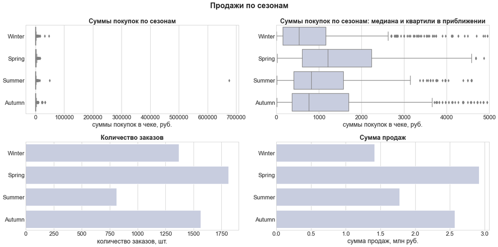

```python
plt.figure(figsize=(20, 10))
sns.set(font_scale=1.5)
plt.style.use('seaborn-whitegrid')
plt.suptitle('Продажи по сезонам', fontweight='bold')

ax1 = plt.subplot(2, 2, 1)
sns.boxplot(data=df.sort_values(by='season_number'), y='season', x='order_receipt', color=color)
plt.title('Суммы покупок по сезонам', fontweight='bold')
plt.xlabel('суммы покупок в чеке, руб.')
plt.ylabel('')

ax2 = plt.subplot(2, 2, 2)
sns.boxplot(data=df.sort_values(by='season_number'), y='season', x='order_receipt', color=color)
plt.title('Суммы покупок по сезонам: медиана и квартили в приближении', fontweight='bold')
plt.xlabel('суммы покупок в чеке, руб.')
plt.ylabel('')
plt.xlim([0, 5000])

ax3 = plt.subplot(2, 2, 3)
sns.barplot(data=df.groupby(['season', 'season_number'], as_index=False).agg({'order_id':'count'})
            .sort_values(by='season_number'), x='order_id', y='season', color=color)
plt.title('Количество заказов', fontweight='bold')
plt.xlabel('количество заказов, шт.')
plt.ylabel('')

ax4 = plt.subplot(2, 2, 4)
data = df.groupby(['season','season_number'], as_index=False).agg({'order_receipt':'sum'})
data['order_receipt_mln'] = data['order_receipt']/1000000
sns.barplot(data=data.sort_values(by='season_number'), x='order_receipt_mln', y='season', color=color)
plt.title('Сумма продаж', fontweight='bold')
plt.xlabel('сумма продаж, млн руб.')
plt.ylabel('')

plt.tight_layout()
plt.show();
```

**Вывод**:

- весна - лидер по количеству заказов, сумме продаж, а также по уровню медианного чека (около 1200 руб.)
- в остальные времена года медианный чек менее 1000 руб.
- лето отстаёт по количеству заказов, а зима по сумме продаж

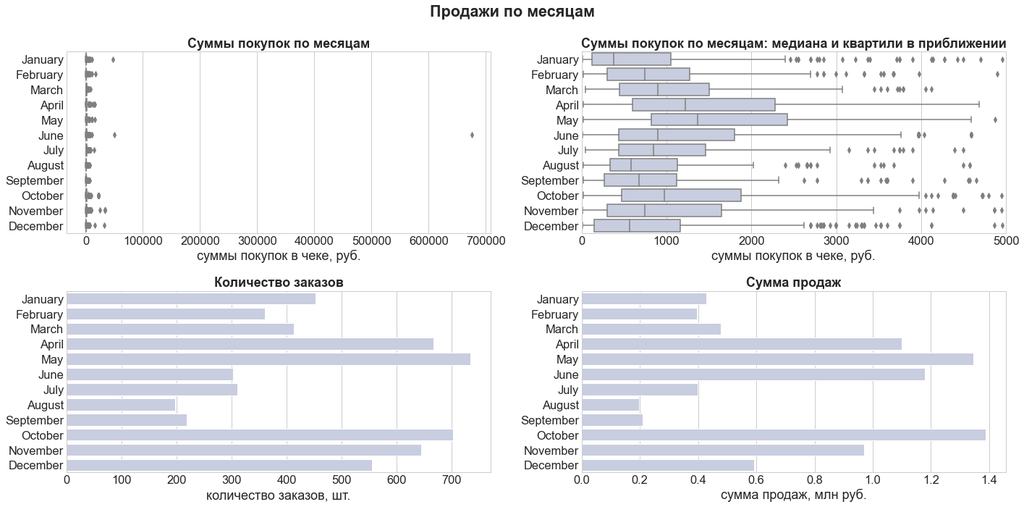

```python
plt.figure(figsize=(20, 10))
sns.set(font_scale=1.5)
plt.style.use('seaborn-whitegrid')
plt.suptitle('Продажи по месяцам', fontweight='bold')

ax1 = plt.subplot(2, 2, 1)
sns.boxplot(data=df.sort_values(by='month'), y='month_name', x='order_receipt', color=color)
plt.title('Суммы покупок по месяцам', fontweight='bold')
plt.xlabel('суммы покупок в чеке, руб.')
plt.ylabel('')

ax2 = plt.subplot(2, 2, 2)
sns.boxplot(data=df.sort_values(by='month'), y='month_name', x='order_receipt', color=color)
plt.title('Суммы покупок по месяцам: медиана и квартили в приближении', fontweight='bold')
plt.xlabel('суммы покупок в чеке, руб.')
plt.ylabel('')
plt.xlim([0, 5000])

ax3 = plt.subplot(2, 2, 3)
sns.barplot(data=df.groupby(['month_name', 'month'], as_index=False).agg({'order_id':'count'}).sort_values(by='month'),
            x='order_id', y='month_name', color=color)
plt.title('Количество заказов', fontweight='bold')
plt.xlabel('количество заказов, шт.')
plt.ylabel('')

ax4 = plt.subplot(2, 2, 4)
data = df.groupby(['month_name', 'month'], as_index=False).agg({'order_receipt':'sum'})
data['order_receipt_mln'] = data['order_receipt']/1000000
sns.barplot(data=data.sort_values(by='month'), x='order_receipt_mln', y='month_name', color=color)
plt.title('Сумма продаж', fontweight='bold')
plt.xlabel('сумма продаж, млн руб.')
plt.ylabel('')

plt.tight_layout()
plt.show();
```

**Вывод**:

- крупные заказы случаются в период новогодних праздников и подготовки к ним (ноябрь, декабрь, январь), а также летом в июне (тогда был зафиксирован заказ на рекордную сумму почти в 700 тыс.руб.)
- сильнее всего медианный чек увеличивается в апреле и мае. Видимо, это связано с подготовкой к отпускам. Тогда же увеличивается количество заказов и следом сумма продаж.
- а вот август и сентябрь финансово неблагоприятные для магазина месяцы по всем показателям

### Продажи по категориям товаров: количество заказов и сумма продаж

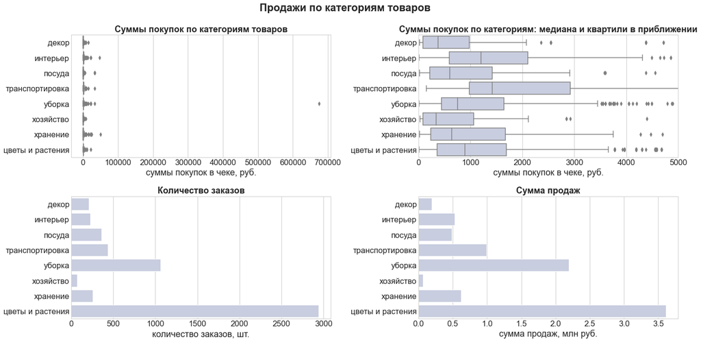

```python
plt.figure(figsize=(20, 10))
sns.set(font_scale=1.5)
plt.style.use('seaborn-whitegrid')
plt.suptitle('Продажи по категориям товаров', fontweight='bold')

ax1 = plt.subplot(2, 2, 1)
sns.boxplot(data=df.sort_values(by='product_category'), y='product_category', x='order_receipt', color=color)
plt.title('Суммы покупок по категориям товаров', fontweight='bold')
plt.xlabel('суммы покупок в чеке, руб.')
plt.ylabel('')

ax2 = plt.subplot(2, 2, 2)
sns.boxplot(data=df.sort_values(by='product_category'), y='product_category', x='order_receipt', color=color)
plt.title('Суммы покупок по категориям: медиана и квартили в приближении', fontweight='bold')
plt.xlabel('суммы покупок в чеке, руб.')
plt.ylabel('')
plt.xlim([0, 5000])

ax3 = plt.subplot(2, 2, 3)
sns.barplot(data=df.groupby('product_category', as_index=False).agg({'order_id':'count'})
            .sort_values(by='product_category'), x='order_id', y='product_category', color=color)
plt.title('Количество заказов', fontweight='bold')
plt.xlabel('количество заказов, шт.')
plt.ylabel('')

ax4 = plt.subplot(2, 2, 4)
data = df.groupby('product_category', as_index=False).agg({'order_receipt':'sum'})
data['order_receipt_mln'] = data['order_receipt']/1000000
sns.barplot(data=data.sort_values(by='product_category'), x='order_receipt_mln', y='product_category', color=color)
plt.title('Сумма продаж', fontweight='bold')
plt.xlabel('сумма продаж, млн руб.')
plt.ylabel('')

plt.tight_layout()
plt.show();
```

**Вывод**:

- самая популярная категория товаров - это "цветы и растения". В этой категории почти 3000 заказов на сумму чуть более 3.5 млн.руб. Однако медианный чек не высокий: менее 1000 руб.
- также популярностью пользуются товары из категории "уборка": более 1000 заказов на общую сумму более 2 млн руб. К этой категории относится аномальный по сумме заказ.
- по медианному чеку категории "транспортировка" и "интерьер" занимают лидирующее положение: это более 1 тыс руб.
- самый низкий медианный чек в категориях "декор" и "хозяйство": это менее 500 руб.

### Покупатели: среднее количество заказов

Проведём некоторые расчёты. Узнаем, сколько покупателей оформило 1 заказ, 2 заказа и т.д.

```python
data = df.groupby('customer_id', as_index=False)['order_id'].nunique()
data = data.groupby('order_id', as_index=False).agg({'customer_id':'count'})
data.columns = ['orders_number', 'customers_cnt']
data
```

|  | orders_number | customers_cnt |
| --- | --- | --- |
| 0 | 1 | 1567 |
| 1 | 2 | 841 |
| 2 | 3 | 18 |
| 3 | 4 | 3 |
| 4 | 5 | 1 |
| 5 | 7 | 1 |
| 6 | 17 | 1 |
| 7 | 35 | 1 |
| 8 | 126 | 1 |

Напишем функцию, которая поможет нам категоризировать эти данные:

```python
def orders_number_category (orders_number):
    """
    Возвращает категорию количества заказов у одного пользователя,
    используя следующие правила:
    - '1 заказ', если у клиента за всю историю покупок 1 заказ;
    - '2 заказа', если 2 заказа;
    - 'от 3 до 5 заказов', если от 3 (включая 3) до 5 заказов (не включая 5);
    - 'более 5 заказов', если больше 5 заказов
    """
    if orders_number == 1:
        return '1 заказ'
    if orders_number == 2:
        return '2 заказа'
    if 3 <= orders_number < 5:
        return 'от 3 до 5 заказов'
    if orders_number >= 5:
        return 'более 5 заказов'
```

Добавляем новый столбец:

```python
data['orders_number_category'] = data['orders_number'].apply(orders_number_category)
data
```

|  | orders_number | customers_cnt | orders_number_category |
| --- | --- | --- | --- |
| 0 | 1 | 1567 | 1 заказ |
| 1 | 2 | 841 | 2 заказа |
| 2 | 3 | 18 | от 3 до 5 заказов |
| 3 | 4 | 3 | от 3 до 5 заказов |
| 4 | 5 | 1 | более 5 заказов |
| 5 | 7 | 1 | более 5 заказов |
| 6 | 17 | 1 | более 5 заказов |
| 7 | 35 | 1 | более 5 заказов |
| 8 | 126 | 1 | более 5 заказов |

Готовим данные к визуализации (нам нужно отсортировать таблицу по порядку увеличения числа заказов):

```python
data = (data.groupby('orders_number_category', as_index=False).agg({'customers_cnt':'sum'})
        .sort_values(by='customers_cnt', ascending=False).reset_index(drop=True))
data
```

|  | orders_number_category | customers_cnt |
| --- | --- | --- |
| 0 | 1 заказ | 1567 |
| 1 | 2 заказа | 841 |
| 2 | от 3 до 5 заказов | 21 |
| 3 | более 5 заказов | 5 |

Теперь строим графики:

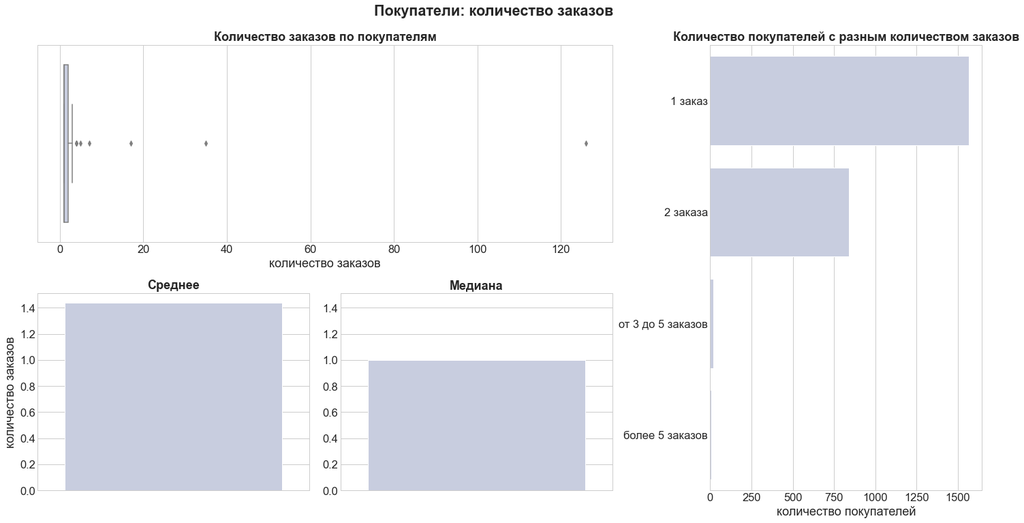

```python
fig = plt.figure(constrained_layout=True, figsize=(20, 10))
sns.set(font_scale=1.5)
plt.style.use('seaborn-whitegrid')
plt.suptitle('Покупатели: количество заказов', fontweight='bold', y=1.05)

spec = gridspec.GridSpec(ncols=3, nrows=2, figure=fig)

table = df.groupby('customer_id', as_index=False)['order_id'].nunique()

ax1 = fig.add_subplot(spec[0, :-1])
plt.title('Количество заказов по покупателям', fontweight='bold')
sns.boxplot(data=table, x='order_id', color=color)
plt.xlabel('количество заказов')
plt.ylabel('')

ax2 = fig.add_subplot(spec[:, -1])
plt.title('Количество покупателей с разным количеством заказов', fontweight='bold')
sns.barplot(data=data, y='orders_number_category', x='customers_cnt', color=color)
plt.xlabel('количество покупателей')
plt.ylabel('')

table_mean = {'name': ['среднее'], 'number': [table['order_id'].mean()]}
table_mean = pd.DataFrame(table_mean)

ax3 = fig.add_subplot(spec[1, :-2])
plt.title('Среднее', fontweight='bold')
sns.barplot(data=table_mean, y='number', color=color)
plt.xlabel('')
plt.ylabel('количество заказов')

table_median = {'name': ['медиана'], 'number': [table['order_id'].median()]}
table_median = pd.DataFrame(table_median)

ax4 = fig.add_subplot(spec[1, -2:-1], sharey=ax3)
plt.title('Медиана', fontweight='bold')
sns.barplot(data=table_median, y='number', color=color)
plt.xlabel('')
plt.ylabel('')

plt.show()
```

**Вывод**:

- чаще всего покупатели совершают 1 заказ
- редко клиенты приходят за покупками несколько раз, однако есть случай, когда клиент совершил более 120 покупок
- среднее количество заказов на покупателя: чуть более одного, а медиана: ровно 1 заказ. небольшая разница между средним и медианой обусловлена небольшим количеством "выбросов"

### Покупатели: средний чек

Рассчитаем, сколько всего денег потратил каждый покупатель:

```python
data = df.groupby('customer_id', as_index=False).agg({'order_receipt':'sum'}).sort_values(by='order_receipt')
data.head()
```

|  | customer_id | order_receipt |
| --- | --- | --- |
| 1421 | 9777b839-4212-41bb-94c2-87de3658248a | 15.0 |
| 328 | 2330d859-e9cb-4c8f-abd0-55f9e27e6745 | 15.0 |
| 2314 | f34611ba-b488-4a88-8d6b-f59a05970fc1 | 22.0 |
| 804 | 55b8d928-77f8-40fc-a2e9-08424d13b0e4 | 22.0 |
| 2208 | e9e94e71-4cd2-47fc-9b3f-1ec96bd2d95e | 22.0 |

Напишем функцию для определения категорий потраченных сумм:

```python
def receipt_category (order_receipt):
    """
    Возвращает категорию общей потраченной суммы на все покупки каждого пользователя,
    используя следующие правила:
    - 'менее 500 руб.', если у клиента общая сумма покупок менее 500 руб.;
    - 'от 500 до 2000 руб.', если сумма от 500 (включая 500 руб.) до 2000 руб. (не включая 2000 руб.)
    -  и т.д.
    """
    if order_receipt < 500:
        return 'менее 500 руб.'
    if 500 <= order_receipt < 2000:
        return 'от 500 до 2000 руб.'
    if 2000 <= order_receipt < 10000:
        return 'от 2 до 10 тыс.руб.'
    if order_receipt >= 10000:
        return 'более 10 тыс.руб.'
```

Добавляем новый столбец:

```python
data['receipt_category'] = data['order_receipt'].apply(receipt_category)
data.head()
```

|  | customer_id | order_receipt | receipt_category |
| --- | --- | --- | --- |
| 1421 | 9777b839-4212-41bb-94c2-87de3658248a | 15.0 | менее 500 руб. |
| 328 | 2330d859-e9cb-4c8f-abd0-55f9e27e6745 | 15.0 | менее 500 руб. |
| 2314 | f34611ba-b488-4a88-8d6b-f59a05970fc1 | 22.0 | менее 500 руб. |
| 804 | 55b8d928-77f8-40fc-a2e9-08424d13b0e4 | 22.0 | менее 500 руб. |
| 2208 | e9e94e71-4cd2-47fc-9b3f-1ec96bd2d95e | 22.0 | менее 500 руб. |

Теперь напишем функцию, чтобы задать порядок полученных категорий от наименьших к наибольшим потраченным суммам:

```python
def number_category (receipt_category):
    """
    Возвращает номер категории общей потраченной суммы по возрастанию объёмов потраченных денег
    """
    if receipt_category == 'менее 500 руб.':
        return 1
    if receipt_category == 'от 500 до 2000 руб.':
        return 2
    if receipt_category == 'от 2 до 10 тыс.руб.':
        return 3
    if receipt_category == 'более 10 тыс.руб.':
        return 4
```

Применяем функцию:

```python
data['number_category'] = data['receipt_category'].apply(number_category)
data.head()
```

|  | customer_id | order_receipt | receipt_category | number_category |
| --- | --- | --- | --- | --- |
| 1421 | 9777b839-4212-41bb-94c2-87de3658248a | 15.0 | менее 500 руб. | 1 |
| 328 | 2330d859-e9cb-4c8f-abd0-55f9e27e6745 | 15.0 | менее 500 руб. | 1 |
| 2314 | f34611ba-b488-4a88-8d6b-f59a05970fc1 | 22.0 | менее 500 руб. | 1 |
| 804 | 55b8d928-77f8-40fc-a2e9-08424d13b0e4 | 22.0 | менее 500 руб. | 1 |
| 2208 | e9e94e71-4cd2-47fc-9b3f-1ec96bd2d95e | 22.0 | менее 500 руб. | 1 |

Готовим данные для визуализации:

```python
data = (data.groupby(['receipt_category', 'number_category'], as_index=False).agg({'customer_id':'count'})
        .sort_values(by='number_category').drop(columns=['number_category']).reset_index(drop=True))
```

Строим графики:

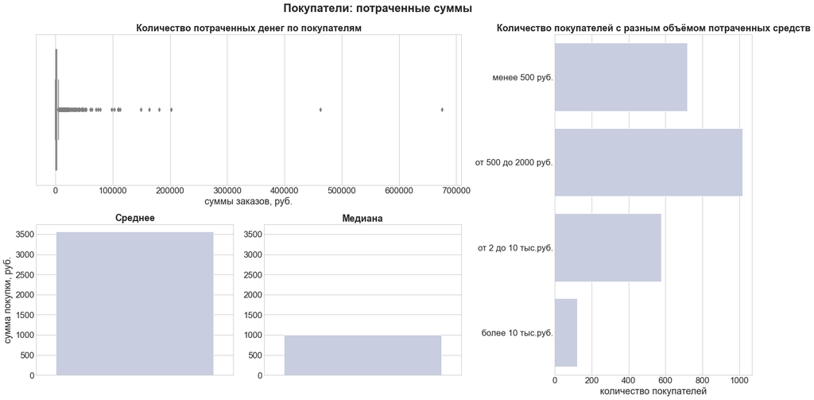

```python
fig = plt.figure(constrained_layout=True, figsize=(20, 10))
sns.set(font_scale=1.5)
plt.style.use('seaborn-whitegrid')
plt.suptitle('Покупатели: потраченные суммы', fontweight='bold', y=1.05)

spec = gridspec.GridSpec(ncols=3, nrows=2, figure=fig)

table = df.groupby('customer_id', as_index=False).agg({'order_receipt':'sum'})

ax1 = fig.add_subplot(spec[0, :-1])
plt.title('Количество потраченных денег по покупателям', fontweight='bold')
sns.boxplot(data=table, x='order_receipt', color=color)
plt.xlabel('суммы заказов, руб.')
plt.ylabel('')

ax2 = fig.add_subplot(spec[:, -1])
plt.title('Количество покупателей с разным объёмом потраченных средств', fontweight='bold')
sns.barplot(data=data, y='receipt_category', x='customer_id', color=color)
plt.xlabel('количество покупателей')
plt.ylabel('')

table_mean = {'name': ['среднее'], 'number': [table['order_receipt'].mean()]}
table_mean = pd.DataFrame(table_mean)

ax3 = fig.add_subplot(spec[1, :-2])
plt.title('Среднее', fontweight='bold')
sns.barplot(data=table_mean, y='number', color=color)
plt.xlabel('')
plt.ylabel('сумма покупки, руб.')

table_median = {'name': ['медиана'], 'number': [table['order_receipt'].median()]}
table_median = pd.DataFrame(table_median)

ax4 = fig.add_subplot(spec[1, -2:-1], sharey=ax3)
plt.title('Медиана', fontweight='bold')
sns.barplot(data=table_median, y='number', color=color)
plt.xlabel('')
plt.ylabel('')

plt.show()
```

**Вывод**:

- чаще всего клиенты тратят на покупки средние суммы - от 500 до 2000 рублей, достаточно много людей тратят маленькие суммы (до 500 рублей)
- и достаточно много клиентов, потративших большие суммы (от 2 до 10 тысяч рублей), а вот клиентов с весомым чеком (более 10 тыс.руб.) немного
- среднее значение чека на одного покупателя: около 3500 рублей, а медиана: 1000 рублей. Здесь, в отличие от ситуации с количеством заказов, есть ощутимая разница между средним и медианой, обусловленная "выбросами"

## Сегментация покупателей по профилю потребления

### Подготовка данных

Подготовим данные для кластеризации. Поскольку нам нужно сегментировать покупателей по уровню потребления, сгруппируем данные по customer_id и добавим данные о потреблении.

Посмотрим, данные о каком количестве покупателей у нас есть:

```python
len(df['customer_id'].unique())
```

```
2434
```

Для того, чтобы значения сильно не выбивались, создидим функцию, которая поможет нам брать в датасет о покупателях не сами значения, а категории значений (например 0 покупок/1 покупка/много покупок в какой-то ценовой категории):

```python
def category_number (column_name):
    """
    Возвращает категорию используя следующие правила:
    - 0, если в столбце значение 0,
    - 1, если значение 1,
    - 2, если значений несколько
    """
    if column_name == 0:
        return 0
    elif column_name == 1:
        return 1
    elif column_name >= 2:
        return 2
```

Создаём датасет, где каждая строка - покупатель, а столбцы - это данные о его уровне потребления:

```python
df['receipt_category'] = df['order_receipt'].apply(receipt_category)
df['receipt_category_number'] = df['receipt_category'].apply(number_category)

customer = (df.groupby('customer_id', as_index=False)
                  .agg({'order_id':'nunique', 'receipt_category':'nunique',
                       'order_receipt':'mean'})
                 .sort_values(by='order_id'))

order_receipt_1 = (df.query('receipt_category_number == 1').groupby('customer_id', as_index=False)
                   .agg({'order_id':'nunique'}))
order_receipt_2 = (df.query('receipt_category_number == 2').groupby('customer_id', as_index=False)
                   .agg({'order_id':'nunique'}))
order_receipt_3 = (df.query('receipt_category_number == 3').groupby('customer_id', as_index=False)
                   .agg({'order_id':'nunique'}))
order_receipt_4 = (df.query('receipt_category_number == 4').groupby('customer_id', as_index=False)
                   .agg({'order_id':'nunique'}))

data_frames = [customer, order_receipt_1, order_receipt_2, order_receipt_3, order_receipt_4]

customer_table = reduce(lambda  left,right: pd.merge(left,right,on=['customer_id'],
                                            how='outer'), data_frames).fillna(0)
customer_table.columns = ['customer_id', 'order_total', 'category_cnt', 'order_receipt_mean','order_receipt_cat_1',
                          'order_receipt_cat_2', 'order_receipt_cat_3', 'order_receipt_cat_4']
customer_table_raw = customer_table
customer_table['receipt_mean_category'] = customer_table['order_receipt_mean'].apply(receipt_category)
customer_table['avg_check_category'] = customer_table['receipt_mean_category'].apply(number_category)
customer_table['category_1'] = customer_table['order_receipt_cat_1'].apply(category_number)
customer_table['category_2'] = customer_table['order_receipt_cat_2'].apply(category_number)
customer_table['category_3'] = customer_table['order_receipt_cat_3'].apply(category_number)
customer_table['category_4'] = customer_table['order_receipt_cat_4'].apply(category_number)
customer_table = customer_table.drop(['receipt_mean_category','order_receipt_cat_1','order_receipt_cat_2',
                                      'order_receipt_cat_3', 'order_receipt_cat_4'], axis=1)
customer_table
```

|  | customer_id | order_total | category_cnt | order_receipt_mean | avg_check_category | category_1 | category_2 | category_3 | category_4 |
| --- | --- | --- | --- | --- | --- | --- | --- | --- | --- |
| 0 | 000d6849-084e-4d9f-ac03-37174eaf60c4 | 1 | 1 | 555.000000 | 2 | 0 | 1 | 0 | 0 |
| 1 | 99fd7fa2-4e47-4522-84b5-bd45176117c0 | 1 | 1 | 74.000000 | 1 | 1 | 0 | 0 | 0 |
| 2 | 99e728ef-b118-477d-95a1-3dab449d2db1 | 1 | 1 | 2324.000000 | 3 | 0 | 0 | 1 | 0 |
| 3 | 9990ce3c-995c-4990-8dc5-75583a0c11d2 | 1 | 1 | 225.000000 | 1 | 1 | 0 | 0 | 0 |
| 4 | 9988a59f-f1ec-4f0c-bb3e-cd0e235ad15e | 1 | 1 | 2658.000000 | 3 | 0 | 0 | 1 | 0 |
| ... | ... | ... | ... | ... | ... | ... | ... | ... | ... |
| 2429 | 0184f535-b60a-4914-a982-231e3f615206 | 5 | 1 | 1417.033333 | 2 | 0 | 2 | 0 | 0 |
| 2430 | b7b865ab-0735-407f-8d0c-31f74d2806cc | 7 | 2 | 711.833333 | 2 | 2 | 2 | 0 | 0 |
| 2431 | 73d1cd35-5e5f-4629-8cf2-3fda829d4e58 | 17 | 3 | 1256.529412 | 2 | 2 | 2 | 2 | 0 |
| 2432 | 4d93d3f6-8b24-403b-a74b-f5173e40d7db | 35 | 3 | 1666.000000 | 2 | 2 | 2 | 2 | 0 |
| 2433 | c971fb21-d54c-4134-938f-16b62ee86d3b | 126 | 3 | 1265.342657 | 2 | 2 | 2 | 2 | 0 |

2434 rows × 9 columns

### Корреляция признаков

Теперь оставим только те количественные значения в нашем датасете, которые будем использовать для кластеризации:

```python
x = customer_table.drop(['customer_id', 'order_receipt_mean'], axis=1)
x.head()
```

|  | order_total | category_cnt | avg_check_category | category_1 | category_2 | category_3 | category_4 |
| --- | --- | --- | --- | --- | --- | --- | --- |
| 0 | 1 | 1 | 2 | 0 | 1 | 0 | 0 |
| 1 | 1 | 1 | 1 | 1 | 0 | 0 | 0 |
| 2 | 1 | 1 | 3 | 0 | 0 | 1 | 0 |
| 3 | 1 | 1 | 1 | 1 | 0 | 0 | 0 |
| 4 | 1 | 1 | 3 | 0 | 0 | 1 | 0 |

Итак, мы будем проводить дальнейшую работу с такими признаками:

**1. order_total - количество заказов**

**2. category_cnt - количество категорий стоимости, в которых у покупателя есть чеки**

Всего, напомню, у нас 4 категории:

- "бюджетная" - до 500 руб.
- "средняя" - от 500 до 2000 рублей
- "дорогая" - от 2 до 10 тысяч рублей
- "очень дорогая" - более 10 тысяч рублей

**3. avg_check_category - категория стоимости среднего чека**

Другими словами, к какой категории относится средний чек:

- 1 - "бюджетный"
- 2 - "средний"
- 3 - "дорогой"
- 4 - "очень дорогой"

**4. сategory_1 - категория количества "бюджетных" чеков**

Для определения категорий использованы следующие условия:

- 0 - 0 чеков, 1 - 1 чек, 2 - несколько чеков

**5. сategory_2 - категория количества "средних" чеков**

**6. сategory_3 - категория количества "дорогих" чеков**

**7. сategory_1 - категория количества "очень дорогих" чеков**

Посмотрим на корреляцию:

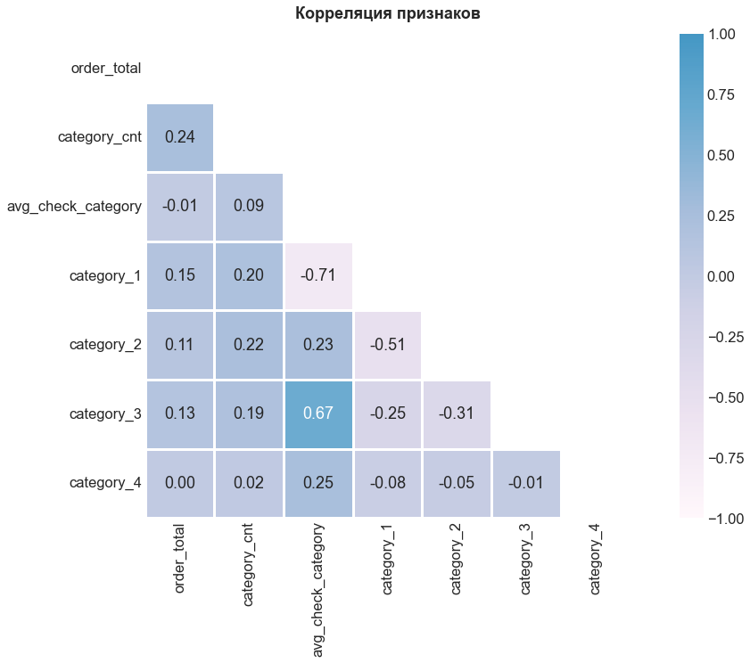

```python
plt.figure(figsize=(20,10))
sns.set(font_scale=1.5)
plt.style.use('seaborn-white')
plt.title('Корреляция признаков', fontweight='bold', y=1.02)
corr_m = x.corr()
sns.heatmap(data=corr_m, square=True, annot=True, fmt=".2f", cmap='PuBuGn', linewidths=3, linecolor='white',
            vmin=-1, vmax=1, center=0.7, mask=np.triu(corr_m))
plt.show();
```

**Вывод**:

Однако эти корреляции не должны помешать дальнейшей работе. Поэтому из данных ничего исключать не будем.

### Стандартизация, матрица расстояний

Стандартизируем данные:

```python
scaler = StandardScaler()
x_sc = scaler.fit_transform(x)
```

Построим матрицу расстояний на стандартизованной матрице признаков:

```python
linked = linkage(x_sc, method='ward')
```

### Дендрограмма

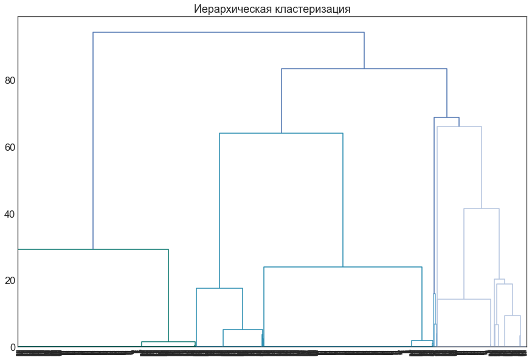

```python
plt.figure(figsize=(15,10))
hierarchy.set_link_color_palette(['#017369', '#258bae', '#68a9cf', '#b4c4df', '#e3dded'])
dendrogram(linked, orientation='top')
plt.title('Иерархическая кластеризация')
plt.show()
```

### Кластеризация

Обучим модель кластеризации на основании алгоритма K-Means и спрогнозируем кластеры клиентов:

```python
km = KMeans(n_clusters=3, n_init=10, random_state=0)
labels = km.fit_predict(x_sc)
```

Сохраняем метки кластера в поле нашего датасета:

```python
customer_table['cluster_km'] = labels
customer_table_raw['cluster_km'] = labels
df = df.merge(customer_table[['customer_id','cluster_km']], how='left', on='customer_id')
```

Добавим буквенные названия кластерам при помощи функции:

```python
def name_category (cluster_km):
    """
    Возвращает буквенное название кластера,
    используя следующие правила:
    - 'A' для кластера 0;
    - 'B' для кластера 1;
    - 'C' для кластера 2
    """
    if cluster_km == 0:
        return 'A'
    if cluster_km == 1:
        return 'B'
    if cluster_km == 2:
        return 'C'
```

```python
customer_table['cluster'] = customer_table['cluster_km'].apply(name_category)
customer_table_raw['cluster'] = customer_table_raw['cluster_km'].apply(name_category)
df['cluster'] = df['cluster_km'].apply(name_category)
```

Посмотрим на количество покупателей в кластерах:

```python
customer_table.groupby('cluster', as_index=False).agg({'customer_id':'count'})
```

|  | cluster | customer_id |
| --- | --- | --- |
| 0 | A | 854 |
| 1 | B | 1135 |
| 2 | C | 445 |

Рассчитаем средние значения по всем признакам для каждого кластера:

```python
cluster_mean = customer_table.groupby(['cluster_km']).mean().T.reset_index().rename_axis(None, axis=1)
cluster_mean.columns = ['features', 'cluster_A', 'cluster_B', 'cluster_C']
cluster_mean
```

|  | features | cluster_A | cluster_B | cluster_C |
| --- | --- | --- | --- | --- |
| 0 | order_total | 1.314988 | 1.394714 | 1.795506 |
| 1 | category_cnt | 1.000000 | 1.282819 | 1.366292 |
| 2 | order_receipt_mean | 233.786376 | 918.285497 | 5162.224755 |
| 3 | avg_check_category | 1.000000 | 1.887225 | 2.822472 |
| 4 | category_1 | 1.305621 | 0.287225 | 0.249438 |
| 5 | category_2 | 0.000000 | 1.096916 | 0.125843 |
| 6 | category_3 | 0.000000 | 0.000000 | 1.017978 |
| 7 | category_4 | 0.000000 | 0.000000 | 0.038202 |

Визуализируем наши данные:

[figure not shown]

```python
fig = plt.figure(constrained_layout=True, figsize=(23, 10))
sns.set(font_scale=1.5)
plt.style.use('seaborn-whitegrid')
plt.suptitle('Кластеры: \n средние значения по всем признакам', fontweight='bold')

spec = gridspec.GridSpec(ncols=4, nrows=2, figure=fig)

ax0 = fig.add_subplot(spec[0, 0])
sns.barplot(data= cluster_mean.iloc[0],  x=['A', 'B', 'C'],
            y=['cluster_A', 'cluster_B', 'cluster_C'], color=color)
plt.title('Количество заказов', fontweight='bold')
plt.xlabel('')
plt.ylabel('')

ax1 = fig.add_subplot(spec[0, 1])
sns.barplot(data= cluster_mean.iloc[1], x=['A', 'B', 'C'],
            y=['cluster_A', 'cluster_B', 'cluster_C'], color=color)
plt.title('Количество категорий чеков', fontweight='bold')
plt.xlabel('')
plt.ylabel('')

ax2 = fig.add_subplot(spec[0, 2])
sns.barplot(data= cluster_mean.iloc[2], x=['A', 'B', 'C'],
            y=['cluster_A', 'cluster_B', 'cluster_C'], color=color)
plt.title('Сумма в чеке', fontweight='bold')
plt.xlabel('')
plt.ylabel('')

ax3 = fig.add_subplot(spec[0, 3])
sns.barplot(data= cluster_mean.iloc[3], x=['A', 'B', 'C'],
             y=['cluster_A', 'cluster_B', 'cluster_C'], color=color)
plt.title('Количество покупок \n с чеком до 500 руб.', fontweight='bold')
plt.xlabel('')
plt.ylabel('')

ax4 = fig.add_subplot(spec[1, 0], sharey=ax3)
sns.barplot(data= cluster_mean.iloc[4], x=['A', 'B', 'C'],
             y=['cluster_A', 'cluster_B', 'cluster_C'], color=color)
plt.title('Количество покупок \n с чеком от 500 до 2000 руб.', fontweight='bold')
plt.xlabel('')
plt.ylabel('')

ax5 = fig.add_subplot(spec[1, 1], sharey=ax3)
sns.barplot(data= cluster_mean.iloc[5], x=['A', 'B', 'C'],
             y=['cluster_A', 'cluster_B', 'cluster_C'], color=color)
plt.title('Количество покупок \n с чеком от 2 до 10 тысяч рублей', fontweight='bold')
plt.xlabel('')
plt.ylabel('')

ax6 = fig.add_subplot(spec[1, 2], sharey=ax3)
sns.barplot(data= cluster_mean.iloc[6], x=['A', 'B', 'C'],
             y=['cluster_A', 'cluster_B', 'cluster_C'], color=color)
plt.title('Количество покупок \n с чеком более 10 тысяч рублей', fontweight='bold')
plt.xlabel('')
plt.ylabel('')

ax7 = fig.add_subplot(spec[1, 3])
cluster_cnt = df.groupby('cluster_km').agg({'customer_id':'nunique'})
cluster_cnt = cluster_cnt['customer_id']
sns.barplot(x=['A', 'B', 'C'], y=cluster_cnt, color=color)
plt.title('Количество клиентов \n в каждом кластере', fontweight='bold')
plt.xlabel('')
plt.ylabel('')

fig.tight_layout()
plt.show();
```

### Статистические тесты

Нас интересует, сработают ли принципы разбивки клиентов на кластеры в дальнейшем, например, при увеличении числа клиентов. То есть, имеют ли кластеры разные уровни потребления случайно, или это статистически значимые различия.

Проверим статистические гипотезы:

- H0: статистически значимых различий в среднем чеке между двумя кластерами нет
- H1: различия есть

Нас интересует ситуация, когда нулевая гипотеза отвергается.

Мы сравним все кластеры парами между собой, и если везде нулевая гипотеза будет отвергнута, значит, мы нашли работающую закономерность разбиения на кластеры. В этом случае возможно будет дать "портрет" пользователя и эффективные рекомендации на основе анализа данных.

Выделим кластеры и вспомним, какого размера выборки:

```python
cluster_A = df.query('cluster =="A"')
cluster_B = df.query('cluster =="B"')
cluster_C = df.query('cluster =="C"')


print(f'Размер кластера А: {len(cluster_A)}')
print(f'Размер кластера B: {len(cluster_B)}')
print(f'Размер кластера C: {len(cluster_C)}')
```

```
Размер кластера А: 1276
Размер кластера B: 2778
Размер кластера C: 1504
```

Проверим на нормальность распределения выборки:

```python
alpha = st.norm.ppf(1-0.05)  # критический уровень статистической значимости

results = st.shapiro(cluster_A['order_receipt'])
p_value = results[1]  # второе значение в массиве результатов (с индексом 1) - p-value

print('p-значение: ', p_value)

if p_value < alpha:
    print('Отвергаем нулевую гипотезу: распределение не нормально')
else:
    print('Не получилось отвергнуть нулевую гипотезу, всё нормально')

results = st.shapiro(cluster_B['order_receipt'])
p_value = results[1]

print('p-значение: ', p_value)

if p_value < alpha:
    print('Отвергаем нулевую гипотезу: распределение не нормально')
else:
    print('Не получилось отвергнуть нулевую гипотезу, всё нормально')

results = st.shapiro(cluster_C['order_receipt'])
p_value = results[1]

print('p-значение: ', p_value)

if p_value < alpha:
    print('Отвергаем нулевую гипотезу: распределение не нормально')
else:
    print('Не получилось отвергнуть нулевую гипотезу, всё нормально')
```

```
p-значение:  2.56384653580005e-23
Отвергаем нулевую гипотезу: распределение не нормально
p-значение:  7.225352857286513e-20
Отвергаем нулевую гипотезу: распределение не нормально
p-значение:  0.0
Отвергаем нулевую гипотезу: распределение не нормально
```

У нас в данных есть выбросы, поэтому применить scipy.stats.ttest_ind не сможем, проведем тест Манна-Уитни:

```python
alpha = st.norm.ppf(1-0.05)  # критический уровень статистической значимости

results = st.mannwhitneyu(cluster_A['order_receipt'], cluster_B['order_receipt'])

print('p-значение: ', results.pvalue)

if results.pvalue < alpha:
    print('Отвергаем нулевую гипотезу: разница статистически значима')
else:
    print(
        'Не получилось отвергнуть нулевую гипотезу, вывод о различии сделать нельзя'
    )
```

```
p-значение:  0.0
Отвергаем нулевую гипотезу: разница статистически значима
```

```python
alpha = st.norm.ppf(1-0.05)  # критический уровень статистической значимости

results = st.mannwhitneyu(cluster_A['order_receipt'], cluster_C['order_receipt'])

print('p-значение: ', results.pvalue)

if results.pvalue < alpha:
    print('Отвергаем нулевую гипотезу: разница статистически значима')
else:
    print(
        'Не получилось отвергнуть нулевую гипотезу, вывод о различии сделать нельзя'
    )
```

```
p-значение:  0.0
Отвергаем нулевую гипотезу: разница статистически значима
```

```python
alpha = st.norm.ppf(1-0.05)  # критический уровень статистической значимости

results = st.mannwhitneyu(cluster_B['order_receipt'], cluster_C['order_receipt'])

print('p-значение: ', results.pvalue)

if results.pvalue < alpha:
    print('Отвергаем нулевую гипотезу: разница статистически значима')
else:
    print(
        'Не получилось отвергнуть нулевую гипотезу, вывод о различии сделать нельзя'
    )
```

```
p-значение:  5.559773926784687e-308
Отвергаем нулевую гипотезу: разница статистически значима
```

Добавим вторую гипотезу, и опять проверим по очереди все кластеры между собой.

Проверим такие статистические гипотезы:

- H0: статистически значимых различий в общей выручке между двумя кластерами нет
- H1: различия есть

Нас опять интересует ситуация, когда нулевая гипотеза отвергается.

```python
alpha = st.norm.ppf(1-0.05) # критический уровень статистической значимости

results = st.mannwhitneyu(cluster_A['price_total'], cluster_B['price_total'])

print('p-значение: ', results.pvalue)

if results.pvalue < alpha:
    print('Отвергаем нулевую гипотезу: разница статистически значима')
else:
    print(
        'Не получилось отвергнуть нулевую гипотезу, вывод о различии сделать нельзя'
    )
```

```
p-значение:  3.221056409982293e-42
Отвергаем нулевую гипотезу: разница статистически значима
```

```python
alpha = st.norm.ppf(1-0.05)  # критический уровень статистической значимости

results = st.mannwhitneyu(cluster_A['price_total'], cluster_C['price_total'])

print('p-значение: ', results.pvalue)

if results.pvalue < alpha:
    print('Отвергаем нулевую гипотезу: разница статистически значима')
else:
    print(
        'Не получилось отвергнуть нулевую гипотезу, вывод о различии сделать нельзя'
    )
```

```
p-значение:  2.2535336122567351e-66
Отвергаем нулевую гипотезу: разница статистически значима
```

```python
alpha = st.norm.ppf(1-0.05)  # критический уровень статистической значимости

results = st.mannwhitneyu(cluster_B['price_total'], cluster_C['price_total'])

print('p-значение: ', results.pvalue)

if results.pvalue < alpha:
    print('Отвергаем нулевую гипотезу: разница статистически значима')
else:
    print(
        'Не получилось отвергнуть нулевую гипотезу, вывод о различии сделать нельзя'
    )
```

```
p-значение:  5.172897183463616e-28
Отвергаем нулевую гипотезу: разница статистически значима
```

**Вывод**:

- статистические тесты показали, что нулевые гипотезы во всех вариантах отвергнуты, значит, для всех кластеров различия в среднем чеке статистически значимы.

Мы совершили корректную разбивку пользователей на кластеры по уровню потребления и теперь можем описать свойства каждого кластера.

## "Портрет" пользователей по кластерам и рекомендации

### Уровень потребления

Визуализируем признаки по уровню потребления во всех кластерах:

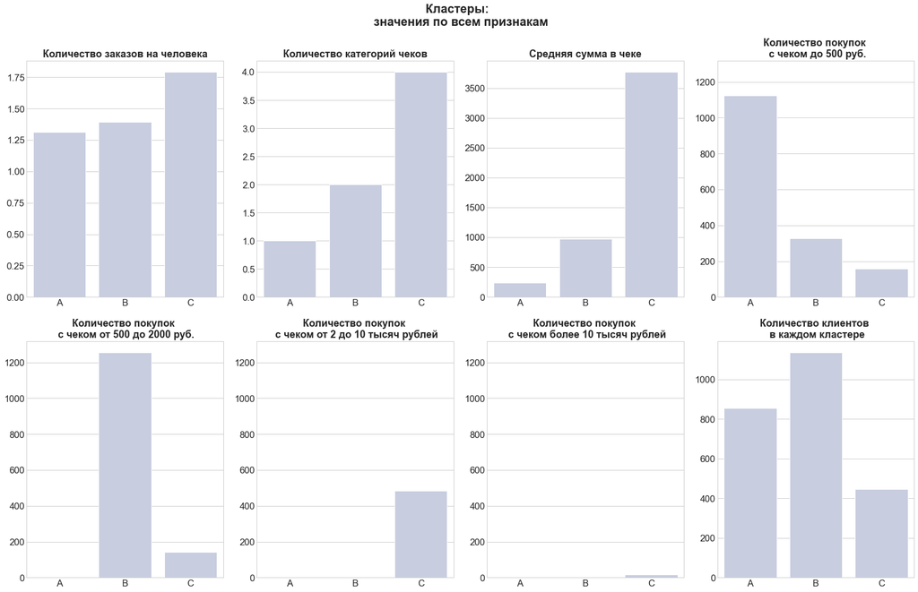

```python
fig = plt.figure(constrained_layout=True, figsize=(23, 15))
sns.set(font_scale=1.5)
plt.style.use('seaborn-whitegrid')
plt.suptitle('Кластеры: \n значения по всем признакам', fontweight='bold')

spec = gridspec.GridSpec(ncols=4, nrows=2, figure=fig)

ax0 = fig.add_subplot(spec[0, 0])
data = df.groupby('cluster', as_index=False).agg({'order_id':'nunique', 'customer_id':'nunique'})
data['order_per_customer'] = data['order_id'] / data['customer_id']
sns.barplot(data=data, y='order_per_customer', x ='cluster', color=color)
plt.title('Количество заказов на человека', fontweight='bold')
plt.xlabel('')
plt.ylabel('')

ax1 = fig.add_subplot(spec[0, 1])
data = df.groupby('cluster', as_index=False).agg({'receipt_category':'nunique'})
sns.barplot(data=data, y='receipt_category', x ='cluster', color=color)
plt.title('Количество категорий чеков', fontweight='bold')
plt.xlabel('')
plt.ylabel('')

ax2 = fig.add_subplot(spec[0, 2])
data = df.groupby('cluster', as_index=False).agg({'order_receipt':'mean'})
sns.barplot(data=data, y='order_receipt', x ='cluster', color=color)
plt.title('Средняя сумма в чеке', fontweight='bold')
plt.xlabel('')
plt.ylabel('')

ax3 = fig.add_subplot(spec[0, 3])
data = customer_table_raw.groupby('cluster', as_index=False).agg({'order_receipt_cat_1':'sum'})
sns.barplot(data=data, y='order_receipt_cat_1', x ='cluster', color=color)
plt.title('Количество покупок \n с чеком до 500 руб.', fontweight='bold')
plt.xlabel('')
plt.ylabel('')

ax4 = fig.add_subplot(spec[1, 0], sharey=ax3)
data = customer_table_raw.groupby('cluster', as_index=False).agg({'order_receipt_cat_2':'sum'})
sns.barplot(data=data, y='order_receipt_cat_2', x ='cluster', color=color)
plt.title('Количество покупок \n с чеком от 500 до 2000 руб.', fontweight='bold')
plt.xlabel('')
plt.ylabel('')

ax5 = fig.add_subplot(spec[1, 1], sharey=ax3)
data = customer_table_raw.groupby('cluster', as_index=False).agg({'order_receipt_cat_3':'sum'})
sns.barplot(data=data, y='order_receipt_cat_3', x ='cluster', color=color)
plt.title('Количество покупок \n с чеком от 2 до 10 тысяч рублей', fontweight='bold')
plt.xlabel('')
plt.ylabel('')

ax6 = fig.add_subplot(spec[1, 2], sharey=ax3)
data = customer_table_raw.groupby('cluster', as_index=False).agg({'order_receipt_cat_4':'sum'})
sns.barplot(data=data, y='order_receipt_cat_4', x ='cluster', color=color)
plt.title('Количество покупок \n с чеком более 10 тысяч рублей', fontweight='bold')
plt.xlabel('')
plt.ylabel('')

ax7 = fig.add_subplot(spec[1, 3])
data = df.groupby('cluster', as_index=False).agg({'customer_id':'nunique'})
sns.barplot(data=data, x='cluster', y='customer_id', color=color)
plt.title('Количество клиентов \n в каждом кластере', fontweight='bold')
plt.xlabel('')
plt.ylabel('')

fig.tight_layout()
plt.show();
```

### Сезонность

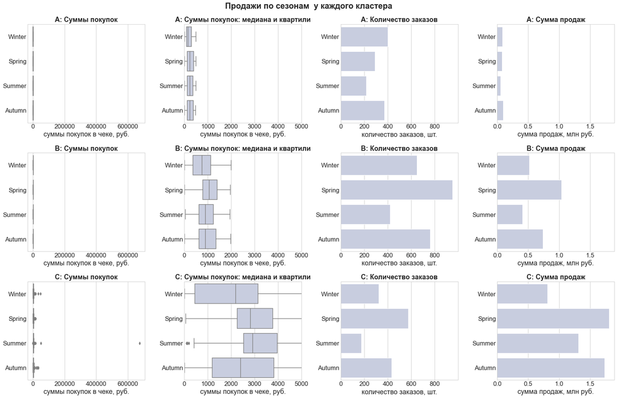

```python
plt.figure(figsize=(23, 15))
sns.set(font_scale=1.5)
plt.style.use('seaborn-whitegrid')
plt.suptitle('Продажи по сезонам  у каждого кластера', fontweight='bold')

ax1 = plt.subplot(3, 4, 1)
sns.boxplot(data=cluster_A.sort_values(by='season_number'), y='season', x='order_receipt', color=color)
plt.title('A: Суммы покупок', fontweight='bold')
plt.xlabel('суммы покупок в чеке, руб.')
plt.ylabel('')

ax2 = plt.subplot(3, 4, 2)
sns.boxplot(data=cluster_A.sort_values(by='season_number'), y='season', x='order_receipt', color=color)
plt.title('A: Суммы покупок: медиана и квартили', fontweight='bold')
plt.xlabel('суммы покупок в чеке, руб.')
plt.ylabel('')
plt.xlim([0, 5000])

ax3 = plt.subplot(3, 4, 3)
sns.barplot(data=cluster_A.groupby(['season', 'season_number'], as_index=False).agg({'order_id':'count'})
            .sort_values(by='season_number'), x='order_id', y='season', color=color)
plt.title('A: Количество заказов', fontweight='bold')
plt.xlabel('количество заказов, шт.')
plt.ylabel('')

ax4 = plt.subplot(3, 4, 4)
data = cluster_A.groupby(['season','season_number'], as_index=False).agg({'order_receipt':'sum'})
data['order_receipt_mln'] = data['order_receipt']/1000000
sns.barplot(data=data.sort_values(by='season_number'), x='order_receipt_mln', y='season', color=color)
plt.title('A: Сумма продаж', fontweight='bold')
plt.xlabel('сумма продаж, млн руб.')
plt.ylabel('')

ax5 = plt.subplot(3, 4, 5, sharex=ax1)
sns.boxplot(data=cluster_B.sort_values(by='season_number'), y='season', x='order_receipt', color=color)
plt.title('B: Суммы покупок', fontweight='bold')
plt.xlabel('суммы покупок в чеке, руб.')
plt.ylabel('')

ax6 = plt.subplot(3, 4, 6)
sns.boxplot(data=cluster_B.sort_values(by='season_number'), y='season', x='order_receipt', color=color)
plt.title('B: Суммы покупок: медиана и квартили', fontweight='bold')
plt.xlabel('суммы покупок в чеке, руб.')
plt.ylabel('')
plt.xlim([0, 5000])

ax7 = plt.subplot(3, 4, 7, sharex=ax3)
sns.barplot(data=cluster_B.groupby(['season', 'season_number'], as_index=False).agg({'order_id':'count'})
            .sort_values(by='season_number'), x='order_id', y='season', color=color)
plt.title('B: Количество заказов', fontweight='bold')
plt.xlabel('количество заказов, шт.')
plt.ylabel('')

ax8 = plt.subplot(3, 4, 8, sharex=ax4)
data = cluster_B.groupby(['season','season_number'], as_index=False).agg({'order_receipt':'sum'})
data['order_receipt_mln'] = data['order_receipt']/1000000
sns.barplot(data=data.sort_values(by='season_number'), x='order_receipt_mln', y='season', color=color)
plt.title('B: Сумма продаж', fontweight='bold')
plt.xlabel('сумма продаж, млн руб.')
plt.ylabel('')

ax9 = plt.subplot(3, 4, 9, sharex=ax1)
sns.boxplot(data=cluster_C.sort_values(by='season_number'), y='season', x='order_receipt', color=color)
plt.title('C: Суммы покупок', fontweight='bold')
plt.xlabel('суммы покупок в чеке, руб.')
plt.ylabel('')

ax10 = plt.subplot(3, 4, 10)
sns.boxplot(data=cluster_C.sort_values(by='season_number'), y='season', x='order_receipt', color=color)
plt.title('C: Суммы покупок: медиана и квартили', fontweight='bold')
plt.xlabel('суммы покупок в чеке, руб.')
plt.ylabel('')
plt.xlim([0, 5000])

ax11 = plt.subplot(3, 4, 11, sharex=ax3)
sns.barplot(data=cluster_C.groupby(['season', 'season_number'], as_index=False).agg({'order_id':'count'})
            .sort_values(by='season_number'), x='order_id', y='season', color=color)
plt.title('C: Количество заказов', fontweight='bold')
plt.xlabel('количество заказов, шт.')
plt.ylabel('')

ax12 = plt.subplot(3, 4, 12, sharex=ax4)
data = cluster_C.groupby(['season','season_number'], as_index=False).agg({'order_receipt':'sum'})
data['order_receipt_mln'] = data['order_receipt']/1000000
sns.barplot(data=data.sort_values(by='season_number'), x='order_receipt_mln', y='season', color=color)
plt.title('C: Сумма продаж', fontweight='bold')
plt.xlabel('сумма продаж, млн руб.')
plt.ylabel('')


plt.tight_layout()
plt.show();
```

**Вывод**:

**Кластер С**:

- весна и осень - более активное время для покупок
- медианный чек зимой снижен

### Категории товаров

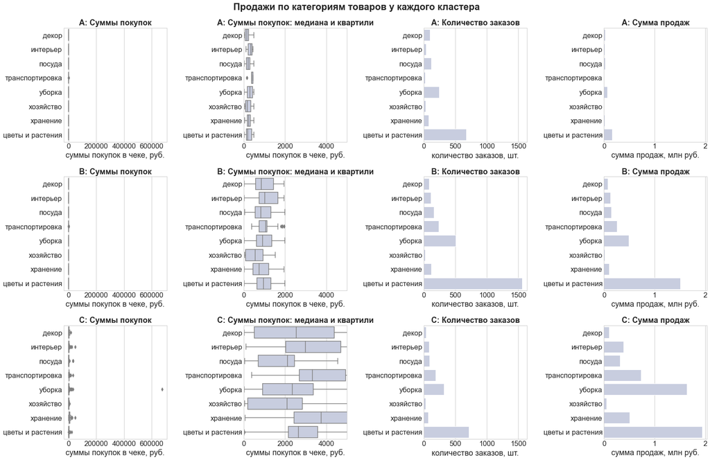

```python
plt.figure(figsize=(23, 15))
sns.set(font_scale=1.5)
plt.style.use('seaborn-whitegrid')
plt.suptitle('Продажи по категориям товаров у каждого кластера', fontweight='bold')

ax1 = plt.subplot(3, 4, 1)
sns.boxplot(data=cluster_A.sort_values(by='product_category'), y='product_category', x='order_receipt', color=color)
plt.title('A: Суммы покупок', fontweight='bold')
plt.xlabel('суммы покупок в чеке, руб.')
plt.ylabel('')

ax2 = plt.subplot(3, 4, 2)
sns.boxplot(data=cluster_A.sort_values(by='product_category'), y='product_category', x='order_receipt', color=color)
plt.title('A: Суммы покупок: медиана и квартили', fontweight='bold')
plt.xlabel('суммы покупок в чеке, руб.')
plt.ylabel('')
plt.xlim([0, 5000])

ax3 = plt.subplot(3, 4, 3)
sns.barplot(data=cluster_A.groupby(['product_category'], as_index=False).agg({'order_id':'count'})
            .sort_values(by='product_category'), x='order_id', y='product_category', color=color)
plt.title('A: Количество заказов', fontweight='bold')
plt.xlabel('количество заказов, шт.')
plt.ylabel('')

ax4 = plt.subplot(3, 4, 4)
data = cluster_A.groupby(['product_category'], as_index=False).agg({'order_receipt':'sum'})
data['order_receipt_mln'] = data['order_receipt']/1000000
sns.barplot(data=data.sort_values(by='product_category'), x='order_receipt_mln', y='product_category', color=color)
plt.title('A: Сумма продаж', fontweight='bold')
plt.xlabel('сумма продаж, млн руб.')
plt.ylabel('')

ax5 = plt.subplot(3, 4, 5, sharex=ax1)
sns.boxplot(data=cluster_B.sort_values(by='product_category'), y='product_category', x='order_receipt', color=color)
plt.title('B: Суммы покупок', fontweight='bold')
plt.xlabel('суммы покупок в чеке, руб.')
plt.ylabel('')

ax6 = plt.subplot(3, 4, 6)
sns.boxplot(data=cluster_B.sort_values(by='product_category'), y='product_category', x='order_receipt', color=color)
plt.title('B: Суммы покупок: медиана и квартили', fontweight='bold')
plt.xlabel('суммы покупок в чеке, руб.')
plt.ylabel('')
plt.xlim([0, 5000])

ax7 = plt.subplot(3, 4, 7, sharex=ax3)
sns.barplot(data=cluster_B.groupby(['product_category'], as_index=False).agg({'order_id':'count'})
            .sort_values(by='product_category'), x='order_id', y='product_category', color=color)
plt.title('B: Количество заказов', fontweight='bold')
plt.xlabel('количество заказов, шт.')
plt.ylabel('')

ax8 = plt.subplot(3, 4, 8, sharex=ax4)
data = cluster_B.groupby(['product_category'], as_index=False).agg({'order_receipt':'sum'})
data['order_receipt_mln'] = data['order_receipt']/1000000
sns.barplot(data=data.sort_values(by='product_category'), x='order_receipt_mln', y='product_category', color=color)
plt.title('B: Сумма продаж', fontweight='bold')
plt.xlabel('сумма продаж, млн руб.')
plt.ylabel('')

ax9 = plt.subplot(3, 4, 9, sharex=ax1)
sns.boxplot(data=cluster_C.sort_values(by='product_category'), y='product_category', x='order_receipt', color=color)
plt.title('C: Суммы покупок', fontweight='bold')
plt.xlabel('суммы покупок в чеке, руб.')
plt.ylabel('')

ax10 = plt.subplot(3, 4, 10)
sns.boxplot(data=cluster_C.sort_values(by='product_category'), y='product_category', x='order_receipt', color=color)
plt.title('C: Суммы покупок: медиана и квартили', fontweight='bold')
plt.xlabel('суммы покупок в чеке, руб.')
plt.ylabel('')
plt.xlim([0, 5000])

ax11 = plt.subplot(3, 4, 11, sharex=ax3)
sns.barplot(data=cluster_C.groupby(['product_category'], as_index=False).agg({'order_id':'count'})
            .sort_values(by='product_category'), x='order_id', y='product_category', color=color)
plt.title('C: Количество заказов', fontweight='bold')
plt.xlabel('количество заказов, шт.')
plt.ylabel('')

ax12 = plt.subplot(3, 4, 12, sharex=ax4)
data = cluster_C.groupby(['product_category'], as_index=False).agg({'order_receipt':'sum'})
data['order_receipt_mln'] = data['order_receipt']/1000000
sns.barplot(data=data.sort_values(by='product_category'), x='order_receipt_mln', y='product_category', color=color)
plt.title('C: Сумма продаж', fontweight='bold')
plt.xlabel('сумма продаж, млн руб.')
plt.ylabel('')


plt.tight_layout()
plt.show();
```

**Вывод**:

Покупатели во всех кластерах активнее всего совершают покупки товаров категории "цветы и растения", на втором месте по популярности - "уборка".

А далее между кластерами можно наблюдать небольшие различия в предпочтении категорий.

**Кластер С**:

- транспортировка
- посуда, хранение

## Презентация

Ссылка на Яндекс диск: https://disk.yandex.ru/i/oCtcR481qmU5eg

## Дашборд

Сылка на Tableau Public (vpn): https://public.tableau.com/authoring/_16818429851800/Dashboard1#1

## Выводы

**Исследовательский анализ данных**:

- обычно чеки заказов небольшие, заказы на несколько десятков тысяч рублей - скорее редкость
- обычно покупатели берут товары на сумму от 500 руб до 4000 тыс.руб., средний чек около 3500 рублей, медианный чек 1000 рублей. Разница обусловлена "выбросами" - несколькими необычно дорогими заказами.
- чаще всего покупатели совершают 1 заказ, редко 2, и очень редко совершают более 2 покупок
- мы можем заметить *сезонность*:
- весна - лидер по количеству заказов, сумме продаж, а также по уровню медианного чека (около 1200 руб.)
- в остальные времена года медианный чек менее 1000 руб.
- лето отстаёт по количеству заказов, а зима по сумме продаж
- крупные заказы случаются в период новогодних праздников и подготовки к ним (ноябрь, декабрь, январь), а также летом в июне (тогда был зафиксирован заказ на рекордную сумму почти в 700 тыс.руб.)
- сильнее всего медианный чек увеличивается в апреле и мае. Видимо, это связано с подготовкой к отпускам. Тогда же увеличивается количество заказов и следом сумма продаж.
- а вот август и сентябрь финансово неблагоприятные для магазина месяцы по всем показателям
- самая популярная *категория товаров* - это "цветы и растения". В этой категории почти 3000 заказов на сумму чуть более 3.5 млн.руб. Однако медианный чек не высокий: менее 1000 руб.
- также популярностью пользуются товары из категории "уборка": более 1000 заказов на общую сумму более 2 млн руб. К этой категории относится аномальный по сумме заказ.
- по медианному чеку категории "транспортировка" и "интерьер" занимают лидирующее положение: это более 1 тыс руб.
- самый низкий медианный чек в категориях "декор" и "хозяйство": это менее 500 руб.

**Сегментация покупателей по уровню потребления**:

Было выделено 3 кластера. Статистические тесты показали, что различия в средних чеках между кластерами является статистически значимыми.

**Кластер А**:

- Весна: цветы и растения, транспортировка
- Перед праздниками 8 марта, 1 сентября, день матери: цветы и растения
- Лето: можно расширить предложения летнего ассортимента (например, добавить вентиляторы)
- Ноябрь, декабрь: интерьер, посуда, все подарочные варианты товаров
- Круглый год: уборка, интерьер, посуда, хранение

**Кластер B**:

- Весна: цветы и растения
- Перед праздниками 8 марта, 1 сентября, день матери: цветы и растения, декор, посуда
- Круглый год: уборка

**Кластер C**:

- Весна: цветы и растения, транспортировка
- Перед праздниками 8 марта, 1 сентября, день матери: цветы и растения
- Лето: можно расширить предложения летнего ассортимента (например, добавить вентиляторы)
- Ноябрь, декабрь: интерьер, посуда, все подарочные варианты товаров
- Круглый год: уборка, посуда, хранение

Исследование выполнила: аналитик данных Малахова Наталья

Мой телеграм-канал: [Дневник аналитика](https://t.me/diary_musician_analyst)

Портфолио: [GitHub](https://github.com/Malakhova-Natalya)

Спасибо за внимание!